# Carotenoids and immune data

Maria Sholola

2023-11-30

# Introduction

Statistical analysis of plasma carotenoids, plasma cytokines and immune cells from randomized cross-over USDA inflammation clinical trial. Subjects consumed both low lycopene tomato (yellow) and high lycopene tomato-soy juices (red) for 4 weeks each.

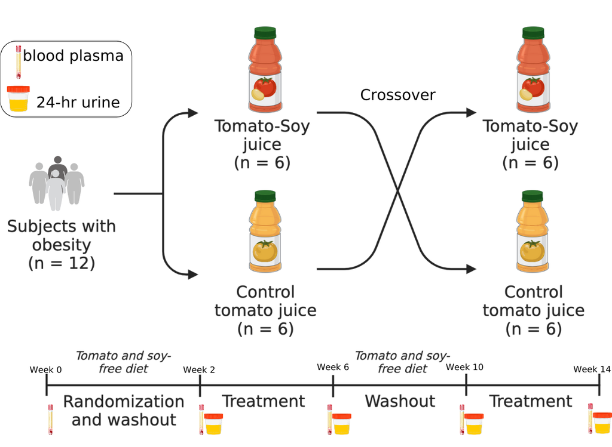

Crossover clinical trial design supplementing individuals with obesity 360 mL of a low carotenoid tomato juice or a high lycopene tomato-soy juice daily. Daily serving of low carotenoid tomato juice consisted of ~1.5mg lycopene/day while high lycopene tomato-soy juice intervention consisted of 54 mg lycopene/day in addition to 210 mg total soy isoflavones/day.

# Load libraries

```r
library(tidyverse) # data wrangling
library(readxl) # read in excel files
library(janitor) # clean up names in dataset
library(corrr) # finding correlations
library(rstatix) # stats
library(lme4) # mixed linear modeling
library(knitr) # aesthetic table viewing
library(lmerTest) # add pvalue column to lmer models
library(purrr) # create functions
library(broom.mixed) # generate tidy data frames for lmer results
library(MuMIn) # lmer model testing using AICc
library(kableExtra)
library(ggthemes)
library(ggtext)
library(ggpubr)
```

# Read in data

```r
# load data
meta_table <- read_excel("CompiledData_Results_Meta.xlsx",
                         sheet = "metadata_corrected_withsequence")

# clean up variable names
meta_table <- clean_names(meta_table)

str(meta_table)
```

```
## tibble [60 × 89] (S3: tbl_df/tbl/data.frame)
##  $ patient_id                          : num [1:60] 6101 6102 6103 6104 6105 ...
##  $ sex                                 : chr [1:60] "F" "M" "F" "M" ...
##  $ age_at_enrollment                   : num [1:60] 58 65 60 54 40 57 68 75 36 46 ...
##  $ bmi_at_enrollment                   : num [1:60] 31.1 36.8 30.3 33.1 30.4 ...
##  $ intervention                        : chr [1:60] "Red" "Red" "Red" "Yellow" ...
##  $ sequence                            : chr [1:60] "R_Y" "R_Y" "R_Y" "Y_R" ...
##  $ intervention_week                   : num [1:60] 2 2 2 2 2 2 2 2 2 2 ...
##  $ pre_post                            : chr [1:60] "pre" "pre" "pre" "pre" ...
##  $ period                              : chr [1:60] "B1" "B1" "B1" "B1" ...
##  $ if_ng                               : num [1:60] 1.16 11.74 0.93 0.63 1.88 ...
##  $ il_1b                               : num [1:60] 15.26 28.75 8.62 11.04 22.5 ...
##  $ il_2                                : chr [1:60] "0.98" "9.32" "0.55000000000000004" "0.65" ...
##  $ il_6                                : num [1:60] 2.18 5.83 2.53 1.29 2.25 ...
##  $ il_8                                : num [1:60] 2.86 4.35 3.93 1.93 4.14 3.05 1.35 2.01 4.43 2.86 ...
```

[output cut: 75 more lines]

## Wrangle

```r
# convert variables that should be factors to factors
meta_table <- meta_table %>%
  mutate(across(.cols = c("patient_id", "period",
                          "intervention", "intervention_week",
                          "pre_post", "sex", "sequence"),
                .fns = as.factor))


# some stuff came in as characters but should be numeric
meta_table <- meta_table %>%
  mutate(across(.cols = c("il_2", "il_10", "il_13", "il_4"),
                .fns = as.numeric))

str(meta_table)
```

```
## tibble [60 × 89] (S3: tbl_df/tbl/data.frame)
##  $ patient_id                          : Factor w/ 12 levels "6101","6102",..: 1 2 3 4 5 6 7 8 9 10 ...
##  $ sex                                 : Factor w/ 2 levels "F","M": 1 2 1 2 2 2 2 1 2 2 ...
##  $ age_at_enrollment                   : num [1:60] 58 65 60 54 40 57 68 75 36 46 ...
##  $ bmi_at_enrollment                   : num [1:60] 31.1 36.8 30.3 33.1 30.4 ...
##  $ intervention                        : Factor w/ 3 levels "Baseline","Red",..: 2 2 2 3 2 3 2 3 3 3 ...
##  $ sequence                            : Factor w/ 2 levels "R_Y","Y_R": 1 1 1 2 1 2 1 2 2 2 ...
##  $ intervention_week                   : Factor w/ 5 levels "0","2","6","10",..: 2 2 2 2 2 2 2 2 2 2 ...
##  $ pre_post                            : Factor w/ 3 levels "baseline","post",..: 3 3 3 3 3 3 3 3 3 3 ...
##  $ period                              : Factor w/ 5 levels "B0","B1","B2",..: 2 2 2 2 2 2 2 2 2 2 ...
##  $ if_ng                               : num [1:60] 1.16 11.74 0.93 0.63 1.88 ...
##  $ il_1b                               : num [1:60] 15.26 28.75 8.62 11.04 22.5 ...
##  $ il_2                                : num [1:60] 0.98 9.32 0.55 0.65 1.8 0.35 0.38 0.05 NA 0.16 ...
##  $ il_6                                : num [1:60] 2.18 5.83 2.53 1.29 2.25 ...
##  $ il_8                                : num [1:60] 2.86 4.35 3.93 1.93 4.14 3.05 1.35 2.01 4.43 2.86 ...
```

[output cut: 75 more lines]

```r
# changing factor levels for pre_post
meta_table$pre_post <- factor(meta_table$pre_post,
                              levels = c("pre", "post"))

levels(meta_table$pre_post)
```

```
## [1] "pre"  "post"
```

```r
# Calculate total_cis_lyc, total_lyc, and total_carotenoids
meta_table <- meta_table %>%
  rename(n5_cis_lyc = x5_cis_lyc) %>%
  mutate(total_cis_lyc = other_cis_lyc + n5_cis_lyc,
         total_lyc = all_trans_lyc + total_cis_lyc,
         total_carotenoids = lutein + zeaxanthin + b_cryptoxanthin +
                             a_carotene + b_carotene + total_lyc)
```

# Carotenoids

## All-trans-lyc levels

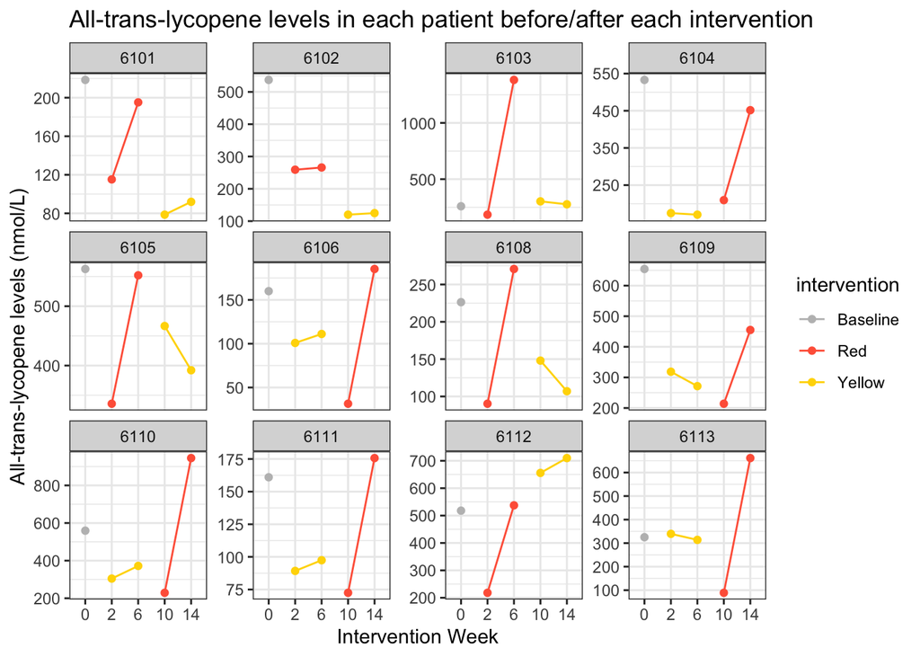

```r
# line plots for each subject at each timepoint
meta_table %>%
  ggplot(aes(x = intervention_week, y = all_trans_lyc, color = intervention)) +
  geom_point() +
  geom_line(aes(group = intervention)) +
  scale_color_manual(values = c("Baseline" = "gray",
                                           "Yellow" = "gold",
                                           "Red" = "tomato1")) +
  facet_wrap(vars(patient_id), scales = "free_y") +
  theme_bw() +
  labs(x = "Intervention Week",
       y = "All-trans-lycopene levels (nmol/L)",
       title = "All-trans-lycopene levels in each patient before/after each intervention")
```

## Total cis-lyc levels

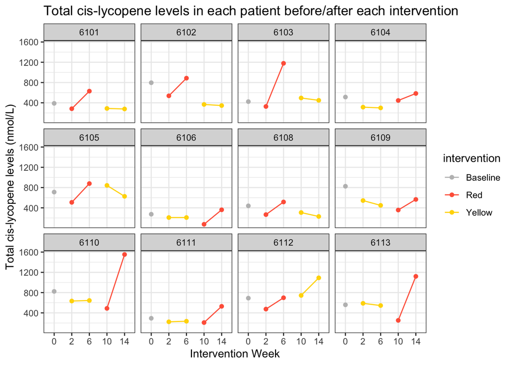

```r
# line plots for each subject at each timepoint
meta_table %>%
  ggplot(aes(x = intervention_week, y = total_cis_lyc, color = intervention)) +
  geom_point() +
  geom_line(aes(group = intervention)) +
  scale_color_manual(values = c("Baseline" = "gray",
                                           "Yellow" = "gold",
                                           "Red" = "tomato1")) +
  facet_wrap(vars(patient_id)) +
  theme_bw() +
  labs(x = "Intervention Week",
       y = "Total cis-lycopene levels (nmol/L)",
       title = "Total cis-lycopene levels in each patient before/after each intervention")
```

## Total lyc levels

### lineplots

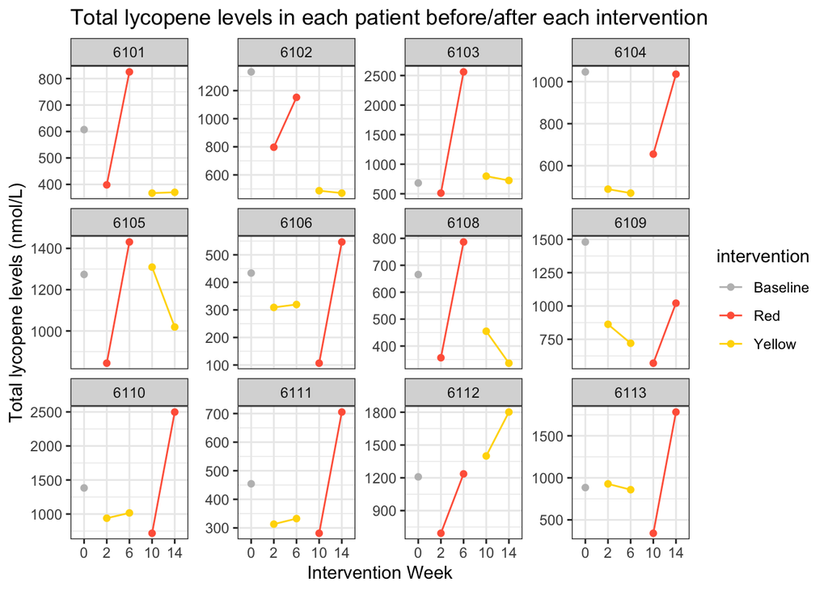

```r
# line plots for each subject at each timepoint
meta_table %>%
  ggplot(aes(x = intervention_week, y = total_lyc, color = intervention)) +
  geom_point() +
  geom_line(aes(group = intervention)) +
  scale_color_manual(values = c("Baseline" = "gray",
                                           "Yellow" = "gold",
                                           "Red" = "tomato1")) +
  facet_wrap(vars(patient_id), scales = "free_y") +
  theme_bw() +
  labs(x = "Intervention Week",
       y = "Total lycopene levels (nmol/L)",
       title = "Total lycopene levels in each patient before/after each intervention")
```

### Boxplots

#### wrangling

```r
# create a more specific pre_post_intervention column
meta_table_edited <- meta_table %>%
  unite(col = "pre_post_intervention",
        c("pre_post","intervention"),
        sep = "_",
        remove = FALSE)

# make pre_post_intervention column factors
meta_table_edited$pre_post_intervention <- as.factor(meta_table_edited$pre_post_intervention)

# relevel factor columns
meta_table_edited$pre_post_intervention <- factor(meta_table_edited$pre_post_intervention, levels = c("pre_Yellow", "post_Yellow", "pre_Red", "post_Red"))

meta_table_edited$intervention <- factor(meta_table_edited$intervention,
                                         levels = c("Yellow", "Red"))
```

```r
# make legend title
legendtitle_ppintervention <- "Timepoint"


# labels
labs_ppintervention <- c("pre control",
                         "post control",
                         "pre Tomato-Soy",
                         "post Tomato-Soy")
```

#### figure

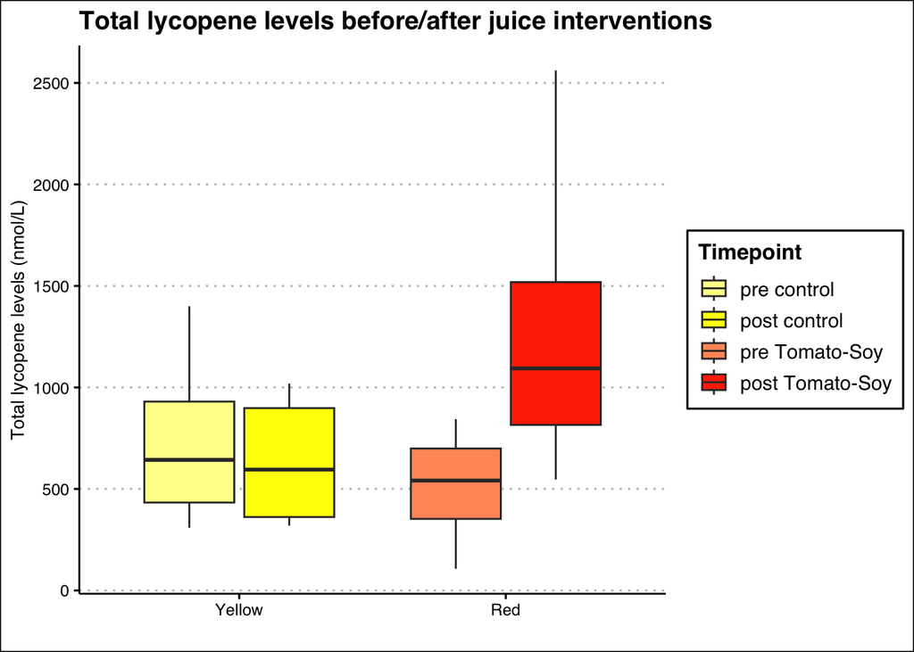

```r
meta_table_edited %>%
  filter(intervention != "Baseline") %>%
  ggplot(aes(x = intervention, y = total_lyc, fill = pre_post_intervention)) +
  geom_boxplot(outlier.shape = NA) +
  scale_fill_manual(legendtitle_ppintervention,
                    values = c("pre_Red" = "#FF9966",
                               "post_Red" = "#FF3300",
                               "pre_Yellow" = "#FFFF99",
                               "post_Yellow" = "yellow"),
                    labels = labs_ppintervention) +
  theme_clean() +
  labs(x = "",
       y = "Total lycopene levels (nmol/L)",
       title = "Total lycopene levels before/after juice interventions")
```

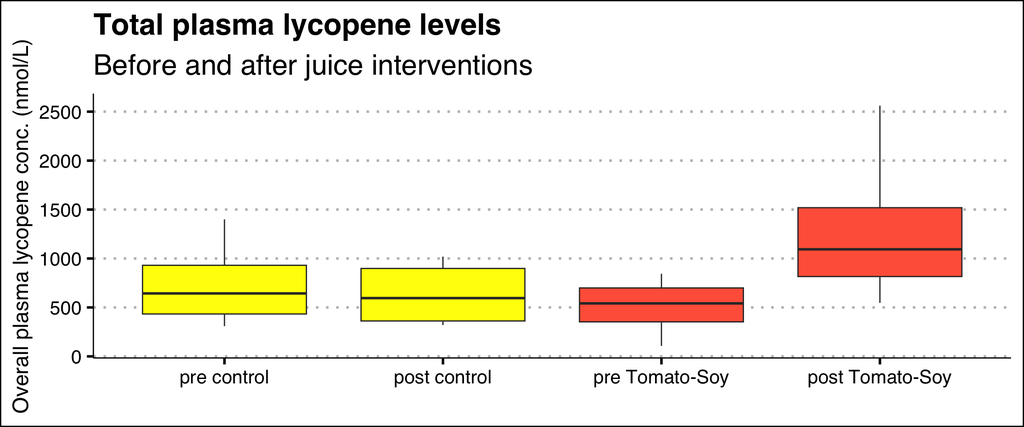

```r
meta_table_edited %>%
  filter(intervention != "Baseline") %>%
  ggplot(aes(x = pre_post_intervention, y = total_lyc, fill = intervention)) +
  geom_boxplot(outlier.shape = NA, show.legend = FALSE) +
  scale_fill_manual(values = c("Red" = "tomato1",
                               "Yellow" = "yellow1")) +
  scale_x_discrete(labels = labs_ppintervention) +
  theme_clean(base_size = 22, base_family = "sans") +
  labs(x = "",
       y = "Overall plasma lycopene conc. (nmol/L)",
       title = "Total plasma lycopene levels",
       subtitle = "Before and after juice interventions")
```

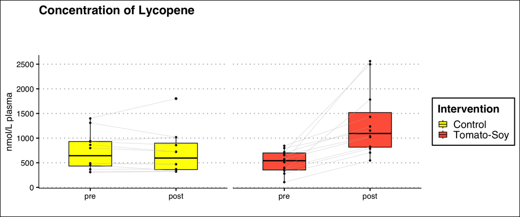

```r
# publish-ready plot
library(ggpubr)

(total_lyc_levels <- meta_table_edited %>%
    filter(intervention != "Baseline") %>%
  ggpaired(x = "pre_post", y = "total_lyc", fill = "intervention", line.color = "gray", line.size = 1, facet.by = "intervention", short.panel.labs = FALSE, panel.labs = list(intervention = c("", ""))) +
  scale_fill_manual(values = c("Red" = "tomato1",
                               "Yellow" = "yellow1"),
                    labels = c("Control", "Tomato-Soy"),
                    name = "Intervention") +
  geom_line(aes(group = patient_id), colour = "gray", linewidth = 0.15) +
  theme_clean(base_size = 18, base_family = "sans") +
  labs(x = "",
       y = "nmol/L plasma",
       title = "Concentration of Lycopene",
       subtitle = ""))
```

#### export

```r
ggsave(filename = "/Users/mariasholola/Documents/GitHub/USDA-Inflammation-Metabolomics/Plots/total-lyc-red-and-yellow-boxplots.svg", plot = total_lyc_levels, width = 12)
```

### Descriptive stats

#### wrangle

```r
# convert meta_table_edited to long format for lycopene
meta_table_lyc_long <- meta_table_edited %>%
  pivot_longer(cols = total_lyc,
               names_to = "total_lycopene",
               values_to = "nmol_per_L")
```

#### Avg/std dev

##### tomsoy

```r
meta_table_lyc_long %>%
  filter(intervention == "Red") %>%
  group_by(pre_post) %>%
  summarize(mean = mean(nmol_per_L),
            stdev = sd(nmol_per_L))
```

```
## # A tibble: 2 × 3
##   pre_post  mean stdev
##   <fct>    <dbl> <dbl>
## 1 pre       523.  228.
## 2 post     1298.  665.
```

##### yellow

```r
meta_table_lyc_long %>%
  filter(intervention == "Yellow") %>%
  group_by(pre_post) %>%
  summarize(mean = mean(nmol_per_L),
            stdev = sd(nmol_per_L))
```

```
## # A tibble: 2 × 3
##   pre_post  mean stdev
##   <fct>    <dbl> <dbl>
## 1 pre       721.  377.
## 2 post      703.  434.
```

#### Mean fold changes

```r
lyc_long_subset <- meta_table_lyc_long %>%
  select(patient_id, nmol_per_L, pre_post_intervention) %>%
  pivot_wider(names_from = pre_post_intervention,
              values_from = nmol_per_L) %>%
  mutate(red_FC = post_Red/pre_Red,
         yellow_FC = post_Yellow/pre_Yellow)

lyc_long_subset %>%
  summarize(mean_red_FC = mean(red_FC),
            mean_yellow_FC = mean(yellow_FC))
```

```
## # A tibble: 1 × 2
##   mean_red_FC mean_yellow_FC
##         <dbl>          <dbl>
## 1        2.83          0.966
```

#### Normality checks

Plot histogram

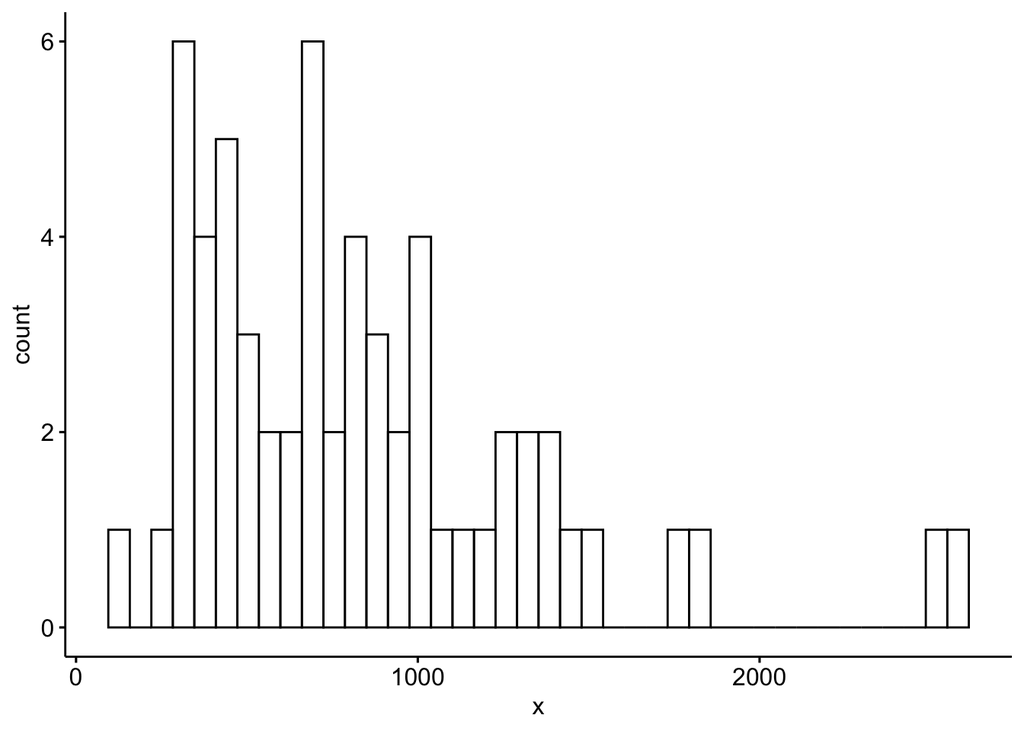

```r
gghistogram(meta_table_lyc_long$nmol_per_L, bins = 40)
```

Shapiro’s normality test

```r
# shapiro normality test for total lycopene

meta_table_lyc_long %>%
  group_by(intervention) %>%
  shapiro_test(vars = "nmol_per_L")
```

```
## # A tibble: 3 × 4
##   intervention variable   statistic       p
##   <fct>        <chr>          <dbl>   <dbl>
## 1 Yellow       nmol_per_L     0.876 0.00698
## 2 Red          nmol_per_L     0.848 0.00202
## 3 <NA>         nmol_per_L     0.913 0.233
```

P val for shapiro test turned out to < 0.05 for both interventions, suggesting data here is not normal. Let’s log transform before running paired t-tests.

#### Log transform

```r
meta_table_lyc_log2_long <- meta_table_lyc_long %>%
  mutate(log2_nmol_per_L = log2(nmol_per_L))
```

Without transforming, here’s a paired t-test

```r
compare_means(nmol_per_L ~ pre_post, meta_table_lyc_log2_long, method = "t.test", paired = TRUE, group.by = "intervention")
```

```
## # A tibble: 2 × 9
##   intervention .y.        group1 group2       p  p.adj p.format p.signif method
##   <fct>        <chr>      <chr>  <chr>    <dbl>  <dbl> <chr>    <chr>    <chr>
## 1 Red          nmol_per_L pre    post   0.00104 0.0021 0.001    **       T-test
## 2 Yellow       nmol_per_L pre    post   0.709   0.71   0.709    ns       T-test
```

##### normality check

Plot histogram

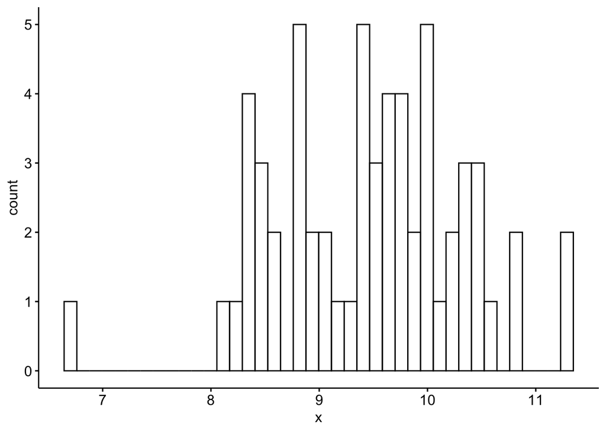

```r
gghistogram(meta_table_lyc_log2_long$log2_nmol_per_L, bins = 40)
```

Shapiro’s normality test

```r
# shapiro normality test for total lycopene
meta_table_lyc_log2_long %>%
  group_by(intervention) %>%
  shapiro_test(vars = "log2_nmol_per_L")
```

```
## # A tibble: 3 × 4
##   intervention variable        statistic      p
##   <fct>        <chr>               <dbl>  <dbl>
## 1 Yellow       log2_nmol_per_L     0.928 0.0869
## 2 Red          log2_nmol_per_L     0.964 0.521
## 3 <NA>         log2_nmol_per_L     0.903 0.173
```

##### paired t test

```r
compare_means(log2_nmol_per_L ~ pre_post, meta_table_lyc_log2_long, method = "t.test", paired = TRUE, group.by = "intervention")
```

```
## # A tibble: 2 × 9
##   intervention .y.        group1 group2       p   p.adj p.format p.signif method
##   <fct>        <chr>      <chr>  <chr>    <dbl>   <dbl> <chr>    <chr>    <chr>
## 1 Red          log2_nmol… pre    post   3.84e-5 7.70e-5 3.8e-05  ****     T-test
## 2 Yellow       log2_nmol… pre    post   3.21e-1 3.2 e-1 0.32     ns       T-test
```

Total lycopene levels are significantly increasing only after post-Red intervention

# Cytokines

```r
# convert cytokines from wide to long
cytokines_long <- meta_table[-c(25:81)] %>%
  pivot_longer(cols = if_ng:il_4,
               names_to = "cytokines",
               values_to = "cyto_conc_pg_ml")
```

```r
#cytokines_long_nona <- na.omit(cytokines_long)
```

*note* 11/30/23: I took this part out since NAs don’t matter for lmm

## Mixed linear modeling

After testing several models, the best model turned out to have pre_post as a fixed variable and patient_id as random effect. Carotenoids added no statistically significant effect to the model, suggesting that carotenoids are not contributing to cytokine levels. Set REML = FALSE when comparing models.

### Sequence effect test

```r
# turn off sci notation
options(scipen = 999)

# sequence effect test lmer model function
cyto_seq_function <- function(cytokines_long) {
  lmer(cyto_conc_pg_ml ~ sequence + (1|patient_id),
       data = cytokines_long,
       REML = TRUE)
}

# break data up into subsets based on cytokine, then apply funtion to each subset
cyto_seq_models <- map(split(cytokines_long,
                         cytokines_long$cytokines),
                   cyto_seq_function)

# create single data frame of results by applying the lmer function to each element in list. apply tidy from broom.mixed package to clean up results
cyto_seq_results <- map_df(cyto_seq_models,
                          tidy,
                          .id = "cytokines")

# extract fixed coefficients for sequence only
cyto_seq_results_coefonly <- cyto_seq_results %>%
  filter(effect == "fixed") %>%
  filter(term != "(Intercept)") %>%
  add_significance(p.col = "p.value",
                   output.col = "p.sig",
                   cutpoints = c(0, 1e-04, 0.001, 0.01, 0.05, 1),
                   symbols = c("****", "***", "**", "*", "ns")
                   )
```

```r
# results
kable(cyto_seq_results_coefonly, format = "markdown", digits = 3)
```

| cytokines | effect | group | term | estimate | std.error | statistic | df | p.value | p.sig |
| --- | --- | --- | --- | --- | --- | --- | --- | --- | --- |
| gm_csf | fixed | NA | sequenceY_R | -27.444 | 24.681 | -1.112 | 10.000 | 0.292 | ns |
| if_ng | fixed | NA | sequenceY_R | -1.194 | 1.477 | -0.808 | 10.000 | 0.438 | ns |
| il_10 | fixed | NA | sequenceY_R | 1.728 | 1.220 | 1.416 | 9.996 | 0.187 | ns |
| il_12p40 | fixed | NA | sequenceY_R | -16.115 | 23.825 | -0.676 | 10.000 | 0.514 | ns |
| il_12p70 | fixed | NA | sequenceY_R | -7.289 | 7.609 | -0.958 | 10.000 | 0.361 | ns |
| il_13 | fixed | NA | sequenceY_R | -18.773 | 13.629 | -1.377 | 10.724 | 0.196 | ns |
| il_1b | fixed | NA | sequenceY_R | -1.552 | 8.358 | -0.186 | 10.000 | 0.856 | ns |
| il_1ra | fixed | NA | sequenceY_R | -2.149 | 1.685 | -1.275 | 10.000 | 0.231 | ns |
| il_2 | fixed | NA | sequenceY_R | -1.585 | 1.440 | -1.101 | 8.191 | 0.302 | ns |
| il_4 | fixed | NA | sequenceY_R | -0.667 | 1.778 | -0.375 | 6.000 | 0.721 | ns |
| il_5 | fixed | NA | sequenceY_R | 1.657 | 3.027 | 0.547 | 10.000 | 0.596 | ns |
| il_6 | fixed | NA | sequenceY_R | -2.432 | 1.896 | -1.283 | 10.000 | 0.229 | ns |
| il_8 | fixed | NA | sequenceY_R | 0.432 | 0.674 | 0.641 | 10.000 | 0.536 | ns |
| mcp_1 | fixed | NA | sequenceY_R | 49.779 | 28.416 | 1.752 | 10.000 | 0.110 | ns |
| tn_fa | fixed | NA | sequenceY_R | -6.730 | 10.112 | -0.666 | 10.000 | 0.521 | ns |

Are there any significant cytokines?

```r
# extract statistically significant cytokines
cytokines_seq_psig <- cyto_seq_results_coefonly %>%
  filter(cyto_seq_results_coefonly$p.value < 0.05)

print(cytokines_seq_psig$cytokines)
```

```
## character(0)
```

- No statistically significant cytokines, suggesting there are no sequence effects

### Intervention comparison

```r
# filter data for post-intervention only
cytokines_post_long <- cytokines_long %>%
  filter(intervention != "Baseline") %>%
  filter(pre_post == "post")
```

```r
# treatment effect test lmer model function
cyto_trt_function <- function(cytokines_post_long) {
  lmer(cyto_conc_pg_ml ~ intervention + (1|patient_id),
       data = cytokines_post_long,
       REML = TRUE)
}

# break data up into subsets based on cytokine, then apply funtion to each subset
cyto_trt_models <- map(split(cytokines_post_long,
                         cytokines_post_long$cytokines),
                   cyto_trt_function)

# create single data frame of results by applying the lmer function to each element in list. apply tidy from broom.mixed package to clean up results
cyto_trt_results <- map_df(cyto_trt_models,
                          tidy,
                          .id = "cytokines")

# extract fixed coefficients for sequence only
cyto_trt_coefonly <- cyto_trt_results %>%
  filter(effect == "fixed") %>%
  filter(term != "(Intercept)") %>%
  add_significance(p.col = "p.value",
                   output.col = "p.sig",
                   cutpoints = c(0, 1e-04, 0.001, 0.01, 0.05, 1),
                   symbols = c("****", "***", "**", "*", "ns")
                   )
```

Results

```r
kable(cyto_trt_coefonly, format = "markdown", digits = 3)
```

| cytokines | effect | group | term | estimate | std.error | statistic | df | p.value | p.sig |
| --- | --- | --- | --- | --- | --- | --- | --- | --- | --- |
| gm_csf | fixed | NA | interventionYellow | -2.237 | 2.904 | -0.770 | 11.000 | 0.457 | ns |
| if_ng | fixed | NA | interventionYellow | 0.081 | 0.213 | 0.380 | 11.000 | 0.711 | ns |
| il_10 | fixed | NA | interventionYellow | 0.121 | 0.158 | 0.766 | 10.035 | 0.461 | ns |
| il_12p40 | fixed | NA | interventionYellow | 6.302 | 5.595 | 1.126 | 11.000 | 0.284 | ns |
| il_12p70 | fixed | NA | interventionYellow | -0.220 | 0.361 | -0.609 | 11.000 | 0.555 | ns |
| il_13 | fixed | NA | interventionYellow | -0.213 | 1.716 | -0.124 | 7.124 | 0.905 | ns |
| il_1b | fixed | NA | interventionYellow | 1.167 | 1.119 | 1.043 | 11.000 | 0.319 | ns |
| il_1ra | fixed | NA | interventionYellow | 0.311 | 0.469 | 0.662 | 11.000 | 0.521 | ns |
| il_2 | fixed | NA | interventionYellow | -0.153 | 0.168 | -0.909 | 6.131 | 0.398 | ns |
| il_4 | fixed | NA | interventionYellow | -0.129 | 0.075 | -1.713 | 7.000 | 0.131 | ns |
| il_5 | fixed | NA | interventionYellow | 0.500 | 0.708 | 0.706 | 11.000 | 0.495 | ns |
| il_6 | fixed | NA | interventionYellow | 0.991 | 0.750 | 1.322 | 11.000 | 0.213 | ns |
| il_8 | fixed | NA | interventionYellow | -0.060 | 0.355 | -0.169 | 11.000 | 0.869 | ns |
| mcp_1 | fixed | NA | interventionYellow | 3.200 | 8.404 | 0.381 | 11.000 | 0.711 | ns |
| tn_fa | fixed | NA | interventionYellow | 0.458 | 1.097 | 0.418 | 11.000 | 0.684 | ns |

```r
# extract statistically significant cytokines
cytokines_trt_psig <- cyto_trt_coefonly %>%
  filter(cyto_trt_coefonly$p.value < 0.05)


print(cytokines_trt_psig$cytokines)
```

```
## character(0)
```

- There are no cytokines with significantly different levels when comparing post-red vs. post-yellow treatment

### Yellow treatment effects

```r
# subset data into yellow results
cytokines_Y <- cytokines_long %>%
  filter(intervention == "Yellow")
```

```r
# treatment effect test lmer model function
cyto_trtY_function <- function(cytokines_Y) {
  lmer(cyto_conc_pg_ml ~ pre_post + (1|patient_id),
       data = cytokines_Y,
       REML = TRUE)
}

# break data up into subsets based on cytokine, then apply funtion to each subset
cyto_trtY_models <- map(split(cytokines_Y,
                         cytokines_Y$cytokines),
                   cyto_trtY_function)

# create single data frame of results by applying the lmer function to each element in list. apply tidy from broom.mixed package to clean up results
cyto_trtY_results <- map_df(cyto_trtY_models,
                          tidy,
                          .id = "cytokines")

# extract fixed coefficients for sequence only
cyto_trtY_coefonly <- cyto_trtY_results %>%
  filter(effect == "fixed") %>%
  filter(term != "(Intercept)") %>%
  add_significance(p.col = "p.value",
                   output.col = "p.sig",
                   cutpoints = c(0, 1e-04, 0.001, 0.01, 0.05, 1),
                   symbols = c("****", "***", "**", "*", "ns")
                   )
```

Results

```r
kable(cyto_trtY_coefonly, format = "markdown", digits = 3)
```

| cytokines | effect | group | term | estimate | std.error | statistic | df | p.value | p.sig |
| --- | --- | --- | --- | --- | --- | --- | --- | --- | --- |
| gm_csf | fixed | NA | pre_postpost | -10.773 | 9.940 | -1.084 | 11.000 | 0.302 | ns |
| if_ng | fixed | NA | pre_postpost | -0.582 | 0.554 | -1.050 | 11.000 | 0.316 | ns |
| il_10 | fixed | NA | pre_postpost | 0.003 | 0.144 | 0.024 | 9.060 | 0.982 | ns |
| il_12p40 | fixed | NA | pre_postpost | -7.124 | 9.540 | -0.747 | 11.000 | 0.471 | ns |
| il_12p70 | fixed | NA | pre_postpost | -3.552 | 3.510 | -1.012 | 11.000 | 0.333 | ns |
| il_13 | fixed | NA | pre_postpost | -10.171 | 8.663 | -1.174 | 7.959 | 0.274 | ns |
| il_1b | fixed | NA | pre_postpost | -4.913 | 3.071 | -1.600 | 11.000 | 0.138 | ns |
| il_1ra | fixed | NA | pre_postpost | -1.743 | 1.465 | -1.189 | 11.000 | 0.259 | ns |
| il_2 | fixed | NA | pre_postpost | -1.097 | 0.952 | -1.151 | 7.491 | 0.285 | ns |
| il_4 | fixed | NA | pre_postpost | -0.752 | 0.722 | -1.043 | 7.000 | 0.332 | ns |
| il_5 | fixed | NA | pre_postpost | -0.906 | 1.413 | -0.641 | 11.000 | 0.535 | ns |
| il_6 | fixed | NA | pre_postpost | -0.614 | 0.659 | -0.932 | 11.000 | 0.372 | ns |
| il_8 | fixed | NA | pre_postpost | 0.130 | 0.296 | 0.439 | 11.000 | 0.669 | ns |
| mcp_1 | fixed | NA | pre_postpost | 1.432 | 5.523 | 0.259 | 11.000 | 0.800 | ns |
| tn_fa | fixed | NA | pre_postpost | -3.615 | 4.206 | -0.859 | 11.000 | 0.408 | ns |

Significant cytokines

```r
# extract statistically significant cytokines
cytokines_trtY_psig <- cyto_trtY_coefonly %>%
  filter(cyto_trtY_coefonly$p.value < 0.05)


print(cytokines_trtY_psig$cytokines)
```

```
## character(0)
```

- No significant cytokines within yellow treatment

### Red treatment effects

```r
# subset data into yellow results
cytokines_R <- cytokines_long %>%
  filter(intervention == "Red")
```

```r
# treatment effect test lmer model function
cyto_trtR_function <- function(cytokines_R) {
  lmer(cyto_conc_pg_ml ~ pre_post + (1|patient_id),
       data = cytokines_R,
       REML = TRUE)
}

# break data up into subsets based on cytokine, then apply funtion to each subset
cyto_trtR_models <- map(split(cytokines_R,
                         cytokines_R$cytokines),
                   cyto_trtR_function)

# create single data frame of results by applying the lmer function to each element in list. apply tidy from broom.mixed package to clean up results
cyto_trtR_results <- map_df(cyto_trtR_models,
                          tidy,
                          .id = "cytokines")

# extract fixed coefficients for sequence only
cyto_trtR_coefonly <- cyto_trtR_results %>%
  filter(effect == "fixed") %>%
  filter(term != "(Intercept)") %>%
  add_significance(p.col = "p.value",
                   output.col = "p.sig",
                   cutpoints = c(0, 1e-04, 0.001, 0.01, 0.05, 1),
                   symbols = c("****", "***", "**", "*", "ns")
                   )
```

Results

```r
kable(cyto_trtR_coefonly, format = "markdown", digits = 3) %>%
  row_spec(11, bold = TRUE)
```

| cytokines | effect | group | term | estimate | std.error | statistic | df | p.value | p.sig |
| --- | --- | --- | --- | --- | --- | --- | --- | --- | --- |
| gm_csf | fixed | NA | pre_postpost | -7.572 | 5.759 | -1.315 | 11.000 | 0.215 | ns |
| if_ng | fixed | NA | pre_postpost | -0.497 | 0.412 | -1.209 | 11.000 | 0.252 | ns |
| il_10 | fixed | NA | pre_postpost | -0.157 | 0.139 | -1.131 | 10.028 | 0.284 | ns |
| il_12p40 | fixed | NA | pre_postpost | -13.373 | 6.652 | -2.010 | 11.000 | 0.070 | ns |
| il_12p70 | fixed | NA | pre_postpost | -3.119 | 2.415 | -1.291 | 11.000 | 0.223 | ns |
| il_13 | fixed | NA | pre_postpost | -5.090 | 4.748 | -1.072 | 7.669 | 0.316 | ns |
| il_1b | fixed | NA | pre_postpost | -1.908 | 1.306 | -1.461 | 11.000 | 0.172 | ns |
| il_1ra | fixed | NA | pre_postpost | -0.435 | 0.453 | -0.961 | 11.000 | 0.357 | ns |
| il_2 | fixed | NA | pre_postpost | -0.522 | 0.556 | -0.938 | 7.313 | 0.378 | ns |
| il_4 | fixed | NA | pre_postpost | -0.581 | 0.527 | -1.104 | 7.000 | 0.306 | ns |
| il_5 | fixed | NA | pre_postpost | -1.808 | 0.815 | -2.220 | 11.000 | 0.048 | * |
| il_6 | fixed | NA | pre_postpost | -1.102 | 0.820 | -1.343 | 11.000 | 0.206 | ns |
| il_8 | fixed | NA | pre_postpost | 0.073 | 0.217 | 0.338 | 11.000 | 0.741 | ns |
| mcp_1 | fixed | NA | pre_postpost | -2.799 | 6.896 | -0.406 | 11.000 | 0.693 | ns |
| tn_fa | fixed | NA | pre_postpost | -4.860 | 2.934 | -1.656 | 11.000 | 0.126 | ns |

Significant cytokines

```r
# extract statistically significant cytokines
cytokines_trtR_psig <- cyto_trtR_coefonly %>%
  filter(cyto_trtR_coefonly$p.value < 0.05)

print(cytokines_trtR_psig$cytokines)
```

```
## [1] "il_5"
```

- IL-5 is the only significantly different cytokine within red intervention. Same p value from t-test (= 0.0484)
- IL-5 on average goes down by ~1.8 pg/mL from pre to post in red intervention

#### IL-5 plots

##### lineplots

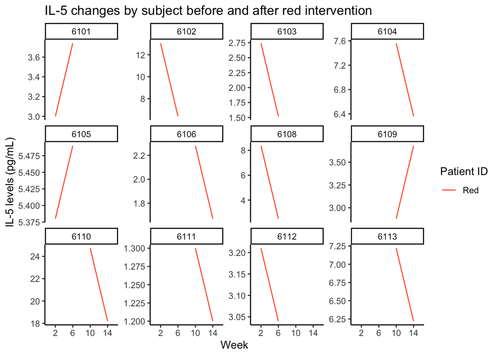

```r
meta_table %>%
  filter(intervention == "Red") %>%
  ggplot(aes(x = intervention_week, y = il_5,
             color = intervention, group = intervention)) +
  geom_line() +
  theme_classic() +
  labs(x = "Week",
       y = "IL-5 levels (pg/mL)",
       title = "IL-5 changes by subject before and after red intervention",
       color = "Patient ID") +
  facet_wrap(~patient_id,
             scales = "free_y") +
  scale_color_manual(values = c("Red" = "tomato1"))
```

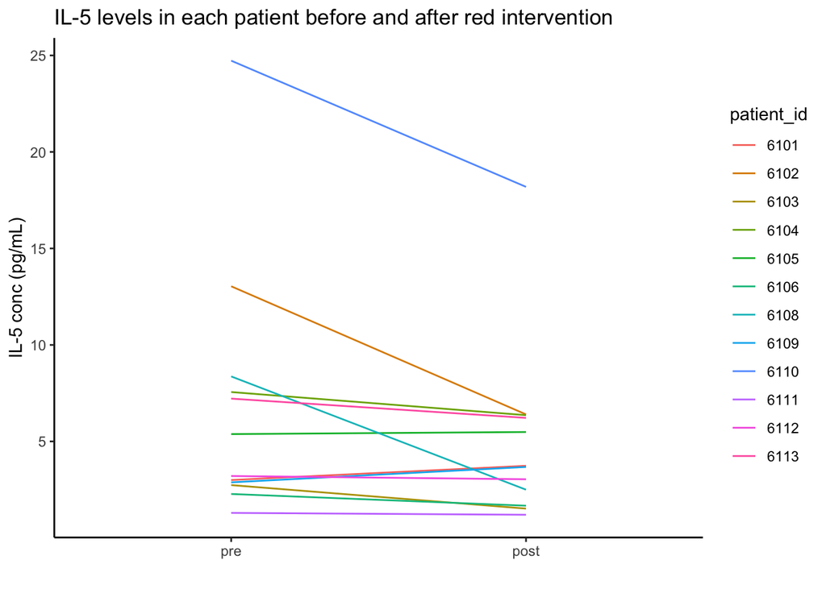

```r
meta_table %>%
  filter(intervention == "Red") %>%
  ggplot(aes(x = pre_post, y = il_5, color = patient_id)) +
  geom_line(aes(group = patient_id)) +
  labs(x = "",
       y = "IL-5 conc (pg/mL)",
       title = "IL-5 levels in each patient before and after red intervention") +
  theme_classic()
```

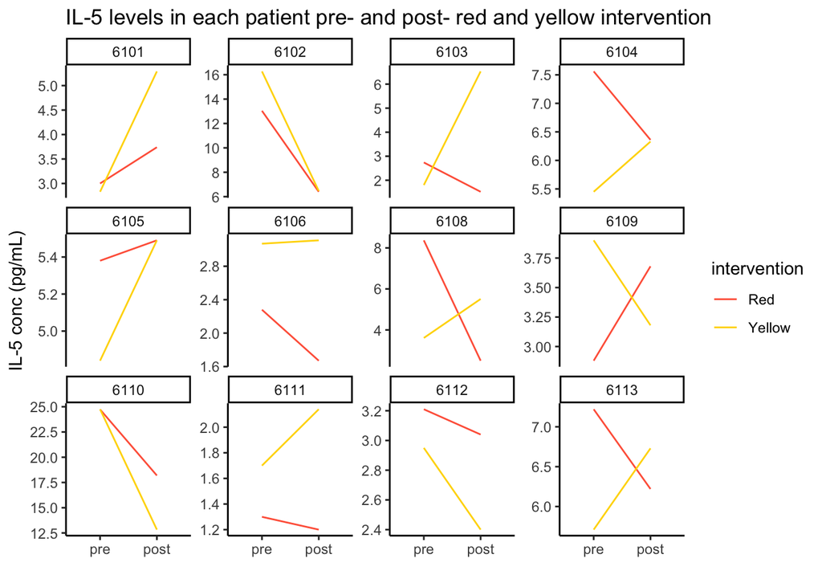

```r
meta_table %>%
  filter(intervention != "Baseline") %>%
  ggplot(aes(x = pre_post, y = il_5, color = intervention)) +
  geom_line(aes(group = intervention)) +
  scale_color_manual(values = c("Yellow" = "gold",
                                "Red" = "tomato1")) +
  facet_wrap(vars(patient_id), scales = "free_y") +
  theme_classic() +
  labs(x = "",
       y = "IL-5 conc (pg/mL)",
       title = "IL-5 levels in each patient pre- and post- red and yellow intervention")
```

##### boxplots

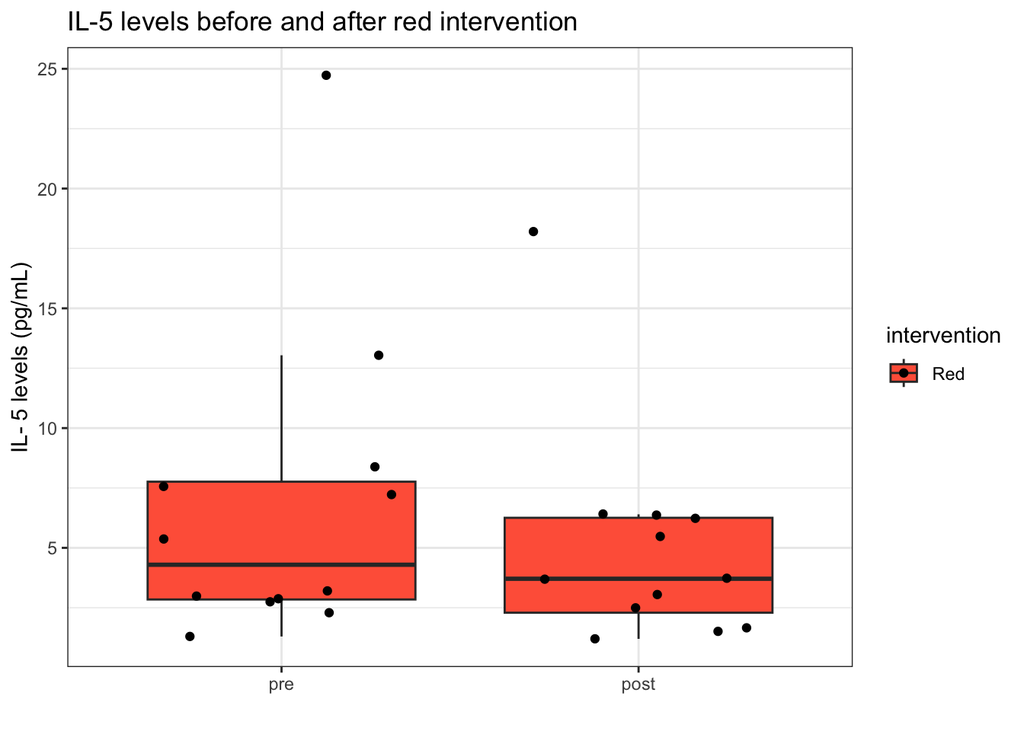

```r
cytokines_long %>%
  filter(intervention == "Red") %>%
  filter(cytokines == "il_5") %>%
  ggplot(aes(x = pre_post, y = cyto_conc_pg_ml, fill = intervention)) +
  geom_boxplot(outlier.shape = NA) +
  geom_jitter() +
  scale_fill_manual(values = c("Red" = "tomato1")) +
  labs(x = "",
       y = "IL- 5 levels (pg/mL)",
       title = "IL-5 levels before and after red intervention") +
  theme_bw()
```

- IL-5 on average goes down by ~1.8 pg/mL from pre to post in red intervention. This is a significant decrease according to the mixed linear model.

# Log-transformed cytokines

I know the data isn’t normally distributed. Mixed linear models do not assume normality of the dependant variable, however the residuals should be normally distributed.

## resid normality checks

I need to figure out how to make a function that extracts makes a QQplot for each model. But since IL-5 was significant, let’s look at how the residuals look for this cytokine (for every comparison) before log transforming

```r
#qqplot_fx <- function(cytokine){
  #qqnorm(resid(cyto_seq_models$cytokine))
  #qqline(resid(cyto_seq_models$cytokine))
#}

#qqplot_fx("il_5")

#cyto_seq_results$
```

### seq

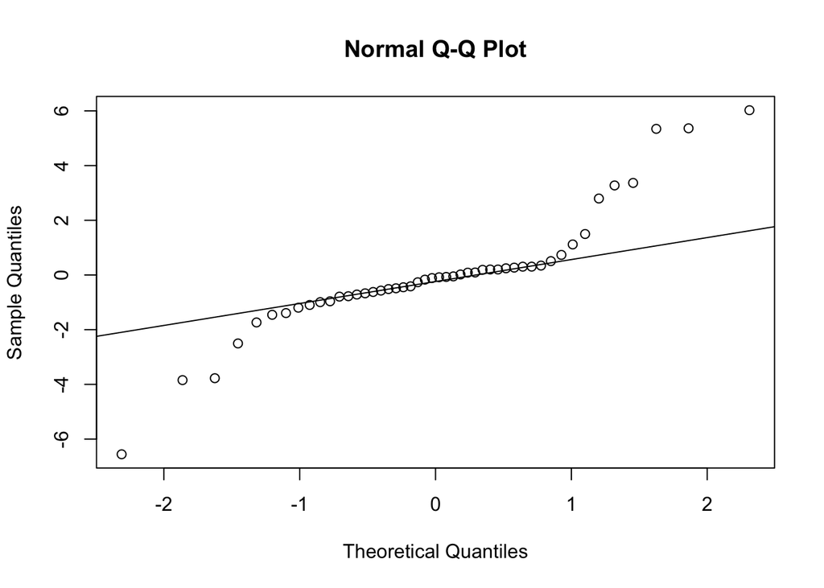

```r
qqnorm(resid(cyto_seq_models$il_5))
qqline(resid(cyto_seq_models$il_5))
```

That doesn’t look good.

### intervention

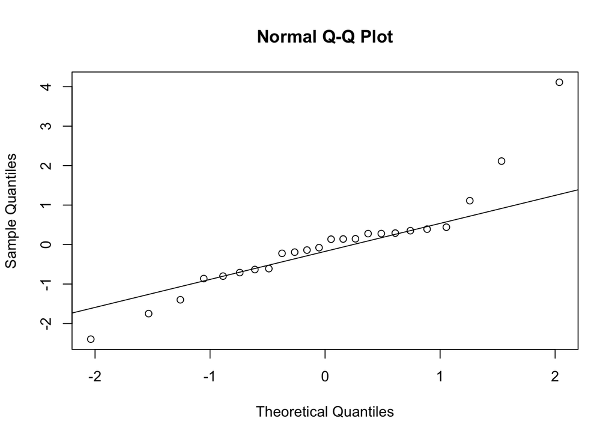

```r
qqnorm(resid(cyto_trt_models$il_5))
qqline(resid(cyto_trt_models$il_5))
```

doesn’t look as bad as sequence

### red

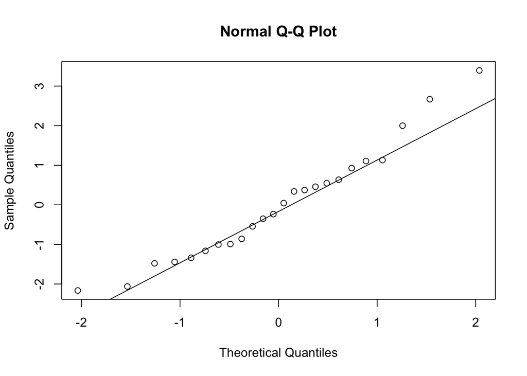

```r
qqnorm(resid(cyto_trtR_models$il_5))
qqline(resid(cyto_trtR_models$il_5))
```

doesn’t look that bad for Red

### yellow

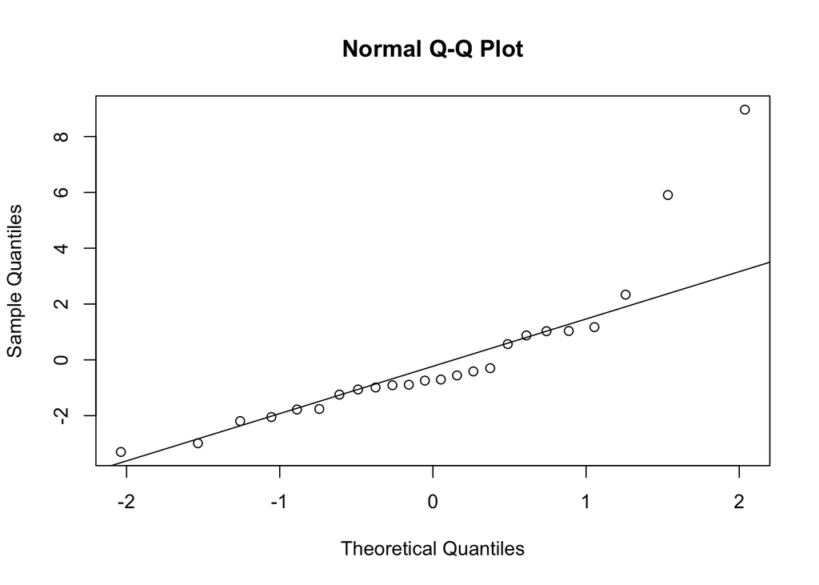

```r
qqnorm(resid(cyto_trtY_models$il_5))
qqline(resid(cyto_trtY_models$il_5))
```

I will log transform the data and perform mixed linear modeling and paired t-tests for every comparison to see how the data compares.

Wrangle

```r
cytokines_log2conc_long <- cytokines_long %>%
  mutate(log2_cyto_conc_pg_ml = log2(cyto_conc_pg_ml))
```

## Mixed linear modeling

### Sequence effect test

We want to make sure there are no seq effects

```r
# sequence effect test lmer model function
cyto_log2_seq_function <- function(cytokines_log2conc_long) {
  lmer(log2_cyto_conc_pg_ml ~ sequence + (1|patient_id),
       data = cytokines_log2conc_long,
       REML = TRUE)
}

# break data up into subsets based on cytokine, then apply funtion to each subset
cyto_log2_seq_models <- map(split(cytokines_log2conc_long,
                         cytokines_log2conc_long$cytokines),
                   cyto_log2_seq_function)

# create single data frame of results by applying the lmer function to each element in list. apply tidy from broom.mixed package to clean up results
cyto_log2_seq_results <- map_df(cyto_log2_seq_models,
                          tidy,
                          .id = "cytokines")

# extract fixed coefficients for sequence only
cyto_log2_seq_results_coefonly <- cyto_log2_seq_results %>%
  filter(effect == "fixed") %>%
  filter(term != "(Intercept)") %>%
  add_significance(p.col = "p.value",
                   output.col = "p.sig",
                   cutpoints = c(0, 1e-04, 0.001, 0.01, 0.05, 1),
                   symbols = c("****", "***", "**", "*", "ns")
                   )
```

#### Resid check

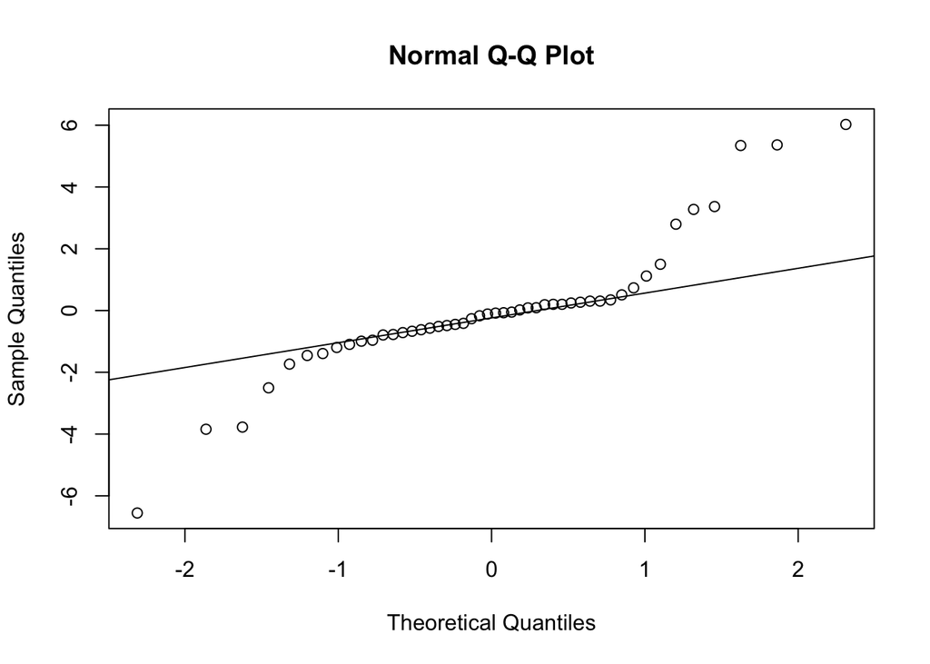

```r
# before log transform
qqnorm(resid(cyto_seq_models$il_5))
qqline(resid(cyto_seq_models$il_5))
```

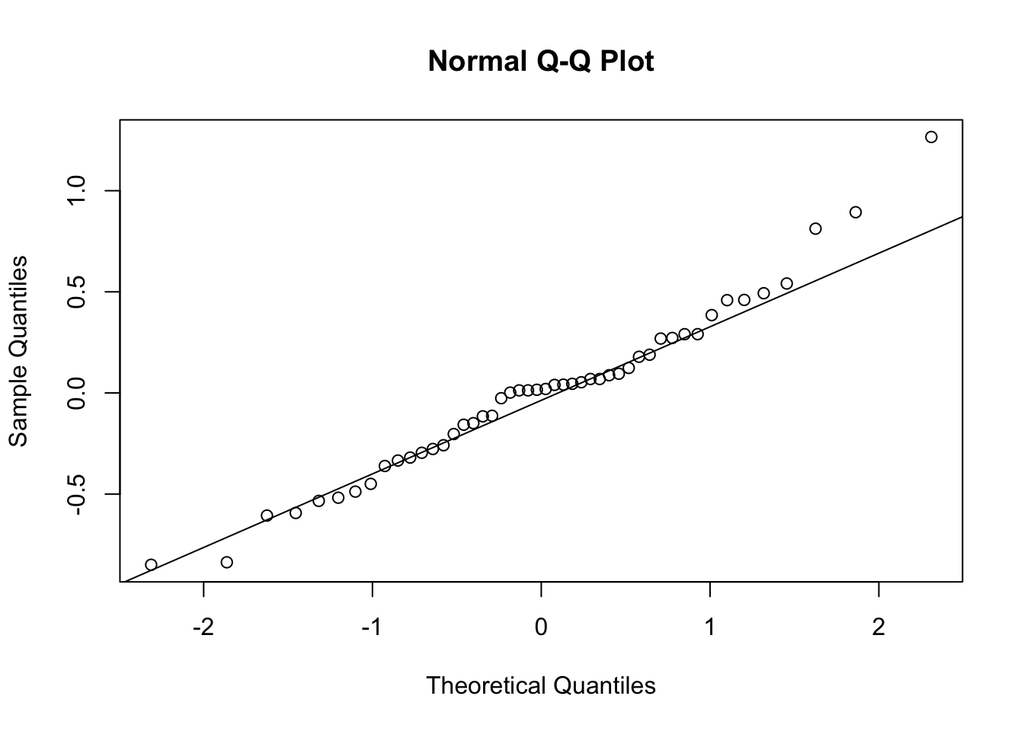

```r
# after log transform
qqnorm(resid(cyto_log2_seq_models$il_5))
qqline(resid(cyto_log2_seq_models$il_5))
```

This looks better after log transform.

#### Results

```r
# results
kable(cyto_log2_seq_results_coefonly, format = "markdown", digits = 3)
```

| cytokines | effect | group | term | estimate | std.error | statistic | df | p.value | p.sig |
| --- | --- | --- | --- | --- | --- | --- | --- | --- | --- |
| gm_csf | fixed | NA | sequenceY_R | -0.703 | 0.813 | -0.864 | 10.000 | 0.408 | ns |
| if_ng | fixed | NA | sequenceY_R | -0.639 | 1.065 | -0.600 | 10.000 | 0.562 | ns |
| il_10 | fixed | NA | sequenceY_R | 0.897 | 1.380 | 0.650 | 9.855 | 0.530 | ns |
| il_12p40 | fixed | NA | sequenceY_R | -0.181 | 0.408 | -0.444 | 10.000 | 0.666 | ns |
| il_12p70 | fixed | NA | sequenceY_R | -0.804 | 0.889 | -0.905 | 10.000 | 0.387 | ns |
| il_13 | fixed | NA | sequenceY_R | -1.081 | 0.848 | -1.275 | 10.230 | 0.230 | ns |
| il_1b | fixed | NA | sequenceY_R | -0.321 | 0.836 | -0.384 | 10.000 | 0.709 | ns |
| il_1ra | fixed | NA | sequenceY_R | -0.570 | 0.518 | -1.101 | 10.000 | 0.297 | ns |
| il_2 | fixed | NA | sequenceY_R | -1.546 | 1.196 | -1.292 | 8.035 | 0.232 | ns |
| il_4 | fixed | NA | sequenceY_R | -0.557 | 1.491 | -0.374 | 6.000 | 0.721 | ns |
| il_5 | fixed | NA | sequenceY_R | 0.115 | 0.595 | 0.194 | 10.000 | 0.850 | ns |
| il_6 | fixed | NA | sequenceY_R | -0.976 | 0.607 | -1.607 | 10.000 | 0.139 | ns |
| il_8 | fixed | NA | sequenceY_R | 0.287 | 0.371 | 0.773 | 10.000 | 0.457 | ns |
| mcp_1 | fixed | NA | sequenceY_R | 0.469 | 0.304 | 1.543 | 10.000 | 0.154 | ns |
| tn_fa | fixed | NA | sequenceY_R | -0.033 | 0.404 | -0.083 | 10.000 | 0.936 | ns |

Are there any significant cytokines?

```r
# extract statistically significant cytokines
cytokines_log2_seq_psig <- cyto_log2_seq_results_coefonly %>%
  filter(cyto_log2_seq_results_coefonly$p.value < 0.05)

print(cytokines_log2_seq_psig$cytokines)
```

```
## character(0)
```

- No statistically significant cytokines, suggesting there are no sequence effects

### Intervention comparison

```r
# filter data for post-intervention only
cytokines_log2conc_post_long <- cytokines_log2conc_long %>%
  filter(intervention != "Baseline") %>%
  filter(pre_post == "post")
```

```r
# treatment effect test lmer model function
cyto_log2_trt_function <- function(cytokines_log2conc_post_long) {
  lmer(log2_cyto_conc_pg_ml ~ intervention + (1|patient_id),
       data = cytokines_log2conc_post_long,
       REML = TRUE)
}

# break data up into subsets based on cytokine, then apply funtion to each subset
cyto_log2_trt_models <- map(split(cytokines_log2conc_post_long,
                         cytokines_log2conc_post_long$cytokines),
                   cyto_log2_trt_function)

# create single data frame of results by applying the lmer function to each element in list. apply tidy from broom.mixed package to clean up results
cyto_log2_trt_results <- map_df(cyto_log2_trt_models,
                          tidy,
                          .id = "cytokines")

# extract fixed coefficients for sequence only
cyto_log2_trt_coefonly <- cyto_log2_trt_results %>%
  filter(effect == "fixed") %>%
  filter(term != "(Intercept)") %>%
  add_significance(p.col = "p.value",
                   output.col = "p.sig",
                   cutpoints = c(0, 1e-04, 0.001, 0.01, 0.05, 1),
                   symbols = c("****", "***", "**", "*", "ns")
                   )
```

##### Resid check

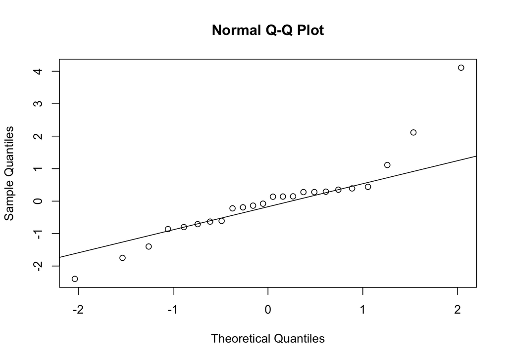

```r
# before log transform
qqnorm(resid(cyto_trt_models$il_5))
qqline(resid(cyto_trt_models$il_5))
```

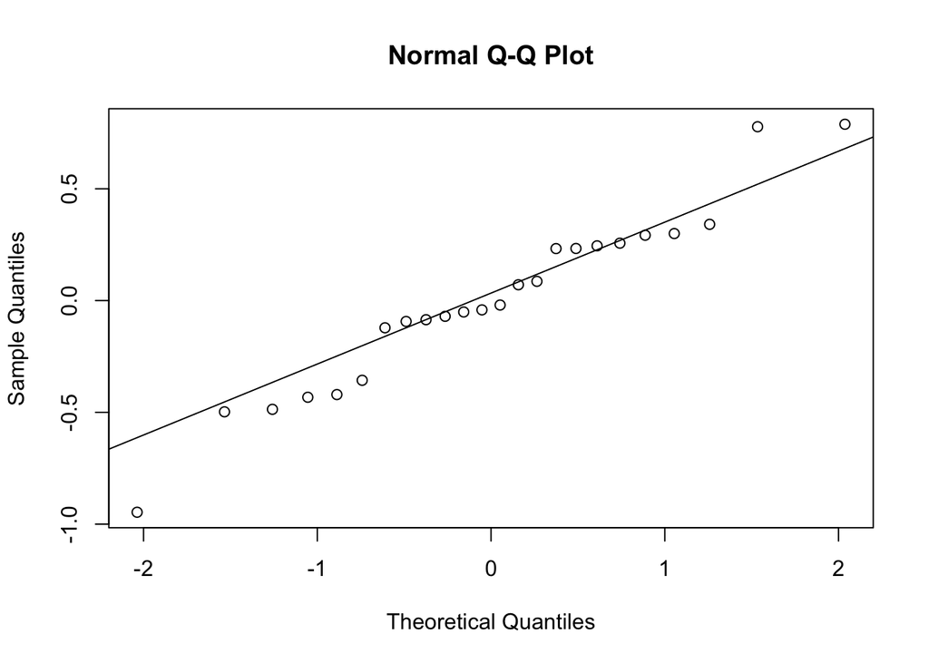

```r
# log transformed
qqnorm(resid(cyto_log2_trt_models$il_5))
qqline(resid(cyto_log2_trt_models$il_5))
```

Don’t know if this helps for intervention comparison

##### Results

```r
kable(cyto_log2_trt_coefonly, format = "markdown", digits = 3)
```

| cytokines | effect | group | term | estimate | std.error | statistic | df | p.value | p.sig |
| --- | --- | --- | --- | --- | --- | --- | --- | --- | --- |
| gm_csf | fixed | NA | interventionYellow | 0.116 | 0.118 | 0.980 | 11.000 | 0.348 | ns |
| if_ng | fixed | NA | interventionYellow | 0.161 | 0.230 | 0.700 | 11.000 | 0.498 | ns |
| il_10 | fixed | NA | interventionYellow | 0.183 | 0.110 | 1.665 | 9.985 | 0.127 | ns |
| il_12p40 | fixed | NA | interventionYellow | 0.177 | 0.153 | 1.159 | 11.000 | 0.271 | ns |
| il_12p70 | fixed | NA | interventionYellow | 0.166 | 0.153 | 1.083 | 11.000 | 0.302 | ns |
| il_13 | fixed | NA | interventionYellow | 0.146 | 0.146 | 0.997 | 7.041 | 0.352 | ns |
| il_1b | fixed | NA | interventionYellow | 0.126 | 0.164 | 0.767 | 11.000 | 0.459 | ns |
| il_1ra | fixed | NA | interventionYellow | 0.083 | 0.155 | 0.535 | 11.000 | 0.603 | ns |
| il_2 | fixed | NA | interventionYellow | 0.216 | 0.291 | 0.745 | 6.079 | 0.484 | ns |
| il_4 | fixed | NA | interventionYellow | -0.052 | 0.070 | -0.743 | 7.000 | 0.482 | ns |
| il_5 | fixed | NA | interventionYellow | 0.379 | 0.216 | 1.749 | 11.000 | 0.108 | ns |
| il_6 | fixed | NA | interventionYellow | 0.331 | 0.263 | 1.260 | 11.000 | 0.234 | ns |
| il_8 | fixed | NA | interventionYellow | -0.105 | 0.156 | -0.674 | 11.000 | 0.514 | ns |
| mcp_1 | fixed | NA | interventionYellow | 0.007 | 0.066 | 0.108 | 11.000 | 0.916 | ns |
| tn_fa | fixed | NA | interventionYellow | 0.035 | 0.071 | 0.499 | 11.000 | 0.627 | ns |

```r
# extract statistically significant cytokines
cytokines_log2_trt_psig <- cyto_log2_trt_coefonly %>%
  filter(cyto_log2_trt_coefonly$p.value < 0.05)


print(cytokines_log2_trt_psig$cytokines)
```

```
## character(0)
```

- There are no cytokines with significantly different levels when comparing post-red vs. post-yellow treatment

### Yellow treatment effects

```r
# subset data into yellow results
cytokines_Y_log2 <- cytokines_log2conc_long %>%
  filter(intervention == "Yellow")
```

```r
# treatment effect test lmer model function
cyto_trtY_log2_function <- function(cytokines_Y_log2) {
  lmer(log2_cyto_conc_pg_ml ~ pre_post + (1|patient_id),
       data = cytokines_Y_log2,
       REML = TRUE)
}

# break data up into subsets based on cytokine, then apply funtion to each subset
cyto_trtY_log2_models <- map(split(cytokines_Y_log2,
                         cytokines_Y_log2$cytokines),
                   cyto_trtY_log2_function)

# create single data frame of results by applying the lmer function to each element in list. apply tidy from broom.mixed package to clean up results
cyto_trtY_log2_results <- map_df(cyto_trtY_log2_models,
                          tidy,
                          .id = "cytokines")

# extract fixed coefficients for sequence only
cyto_trtY_log2_coefonly <- cyto_trtY_log2_results %>%
  filter(effect == "fixed") %>%
  filter(term != "(Intercept)") %>%
  add_significance(p.col = "p.value",
                   output.col = "p.sig",
                   cutpoints = c(0, 1e-04, 0.001, 0.01, 0.05, 1),
                   symbols = c("****", "***", "**", "*", "ns")
                   )
```

##### Resid check

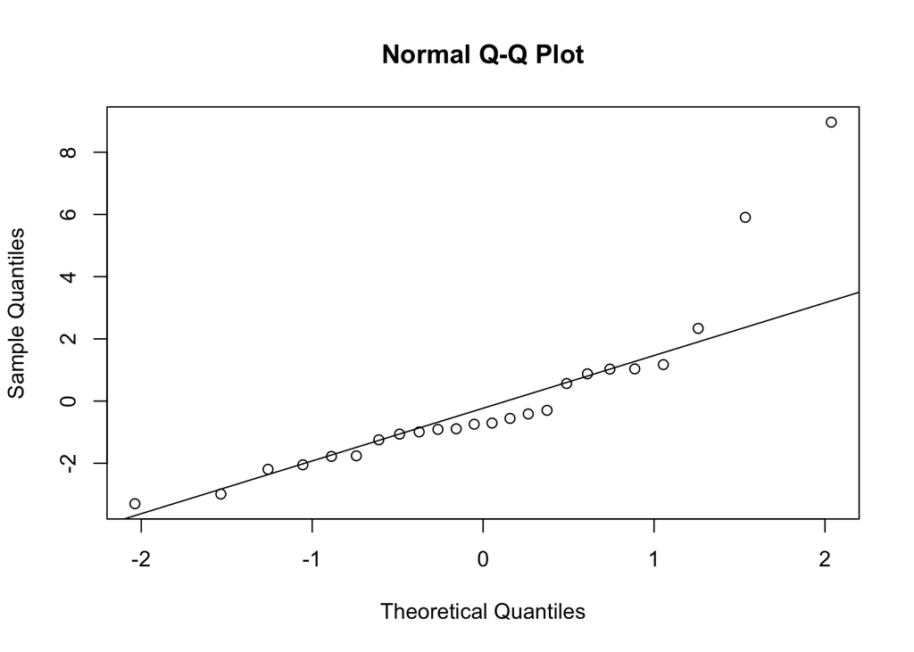

```r
# before log transform
qqnorm(resid(cyto_trtY_models$il_5))
qqline(resid(cyto_trtY_models$il_5))
```

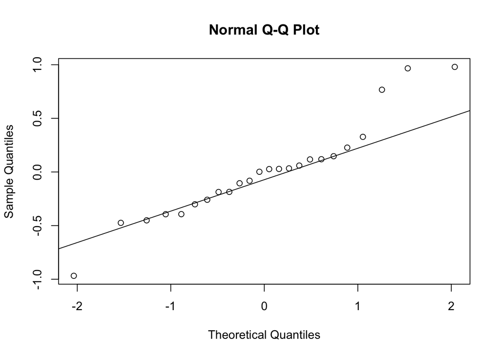

```r
# after log transform
qqnorm(resid(cyto_trtY_log2_models$il_5))
qqline(resid(cyto_trtY_log2_models$il_5))
```

##### Results

```r
kable(cyto_trtY_log2_coefonly, format = "markdown", digits = 3)
```

| cytokines | effect | group | term | estimate | std.error | statistic | df | p.value | p.sig |
| --- | --- | --- | --- | --- | --- | --- | --- | --- | --- |
| gm_csf | fixed | NA | pre_postpost | -0.183 | 0.135 | -1.353 | 11.000 | 0.203 | ns |
| if_ng | fixed | NA | pre_postpost | -0.235 | 0.165 | -1.423 | 11.000 | 0.182 | ns |
| il_10 | fixed | NA | pre_postpost | -0.241 | 0.226 | -1.066 | 8.920 | 0.314 | ns |
| il_12p40 | fixed | NA | pre_postpost | -0.068 | 0.126 | -0.543 | 11.000 | 0.598 | ns |
| il_12p70 | fixed | NA | pre_postpost | -0.053 | 0.145 | -0.365 | 11.000 | 0.722 | ns |
| il_13 | fixed | NA | pre_postpost | -0.130 | 0.242 | -0.539 | 6.933 | 0.607 | ns |
| il_1b | fixed | NA | pre_postpost | -0.206 | 0.208 | -0.991 | 11.000 | 0.343 | ns |
| il_1ra | fixed | NA | pre_postpost | -0.213 | 0.220 | -0.970 | 11.000 | 0.353 | ns |
| il_2 | fixed | NA | pre_postpost | -0.029 | 0.338 | -0.087 | 7.055 | 0.933 | ns |
| il_4 | fixed | NA | pre_postpost | -0.121 | 0.192 | -0.633 | 7.000 | 0.547 | ns |
| il_5 | fixed | NA | pre_postpost | 0.124 | 0.239 | 0.518 | 11.000 | 0.615 | ns |
| il_6 | fixed | NA | pre_postpost | -0.125 | 0.356 | -0.350 | 11.000 | 0.733 | ns |
| il_8 | fixed | NA | pre_postpost | -0.024 | 0.141 | -0.170 | 11.000 | 0.868 | ns |
| mcp_1 | fixed | NA | pre_postpost | -0.012 | 0.043 | -0.278 | 11.000 | 0.786 | ns |
| tn_fa | fixed | NA | pre_postpost | -0.082 | 0.094 | -0.876 | 11.000 | 0.400 | ns |

Significant cytokines

```r
# extract statistically significant cytokines
cytokines_trtY_log2_psig <- cyto_trtY_log2_coefonly %>%
  filter(cyto_trtY_log2_coefonly$p.value < 0.05)


print(cytokines_trtY_log2_psig$cytokines)
```

```
## character(0)
```

- No significant cytokines within yellow treatment

### Red treatment effects

```r
# subset data into yellow results
cytokines_R_log2 <- cytokines_log2conc_long %>%
  filter(intervention == "Red")
```

```r
# treatment effect test lmer model function
cyto_trtR_log2_function <- function(cytokines_R_log2) {
  lmer(log2_cyto_conc_pg_ml ~ pre_post + (1|patient_id),
       data = cytokines_R_log2,
       REML = TRUE)
}

# break data up into subsets based on cytokine, then apply funtion to each subset
cyto_trtR_log2_models <- map(split(cytokines_R_log2,
                         cytokines_R_log2$cytokines),
                   cyto_trtR_log2_function)

# create single data frame of results by applying the lmer function to each element in list. apply tidy from broom.mixed package to clean up results
cyto_trtR_log2_results <- map_df(cyto_trtR_log2_models,
                          tidy,
                          .id = "cytokines")

# extract fixed coefficients for sequence only
cyto_trtR_log2coefonly <- cyto_trtR_log2_results %>%
  filter(effect == "fixed") %>%
  filter(term != "(Intercept)") %>%
  add_significance(p.col = "p.value",
                   output.col = "p.sig",
                   cutpoints = c(0, 1e-04, 0.001, 0.01, 0.05, 1),
                   symbols = c("****", "***", "**", "*", "ns")
                   )
```

##### Resid check

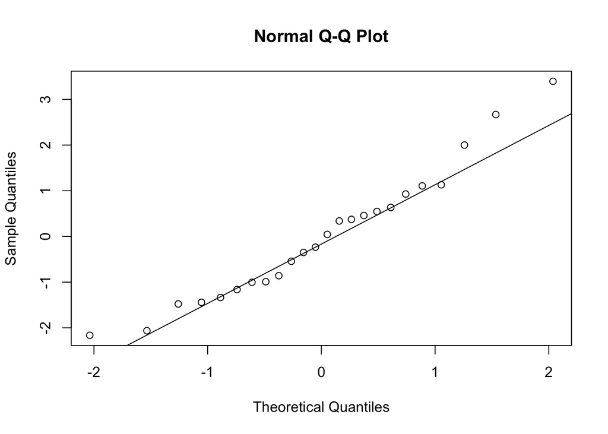

```r
# before log transform
qqnorm(resid(cyto_trtR_models$il_5))
qqline(resid(cyto_trtR_models$il_5))
```

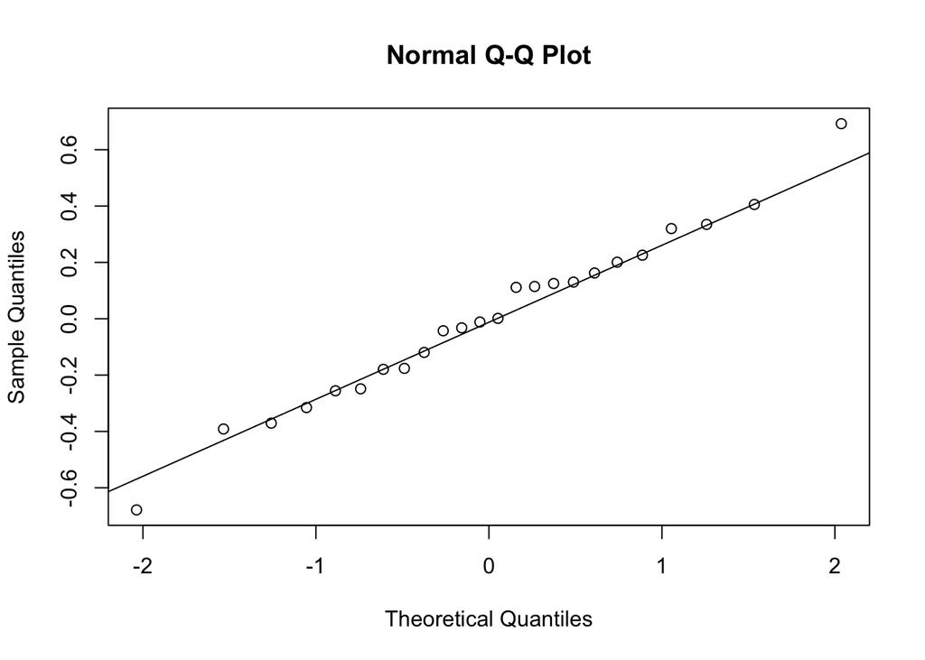

```r
# log transformed
qqnorm(resid(cyto_trtR_log2_models$il_5))
qqline(resid(cyto_trtR_log2_models$il_5))
```

##### Results

```r
kable(cyto_trtR_log2coefonly, format = "markdown", digits = 3)
```

| cytokines | effect | group | term | estimate | std.error | statistic | df | p.value | p.sig |
| --- | --- | --- | --- | --- | --- | --- | --- | --- | --- |
| gm_csf | fixed | NA | pre_postpost | -0.308 | 0.103 | -2.985 | 11.000 | 0.012 | * |
| if_ng | fixed | NA | pre_postpost | -0.307 | 0.197 | -1.559 | 11.000 | 0.147 | ns |
| il_10 | fixed | NA | pre_postpost | -0.137 | 0.422 | -0.325 | 9.926 | 0.752 | ns |
| il_12p40 | fixed | NA | pre_postpost | -0.288 | 0.156 | -1.840 | 11.000 | 0.093 | ns |
| il_12p70 | fixed | NA | pre_postpost | -0.622 | 0.240 | -2.596 | 11.000 | 0.025 | * |
| il_13 | fixed | NA | pre_postpost | -0.130 | 0.199 | -0.652 | 7.181 | 0.535 | ns |
| il_1b | fixed | NA | pre_postpost | -0.227 | 0.164 | -1.387 | 11.000 | 0.193 | ns |
| il_1ra | fixed | NA | pre_postpost | -0.109 | 0.120 | -0.912 | 11.000 | 0.381 | ns |
| il_2 | fixed | NA | pre_postpost | -0.273 | 0.277 | -0.988 | 7.142 | 0.356 | ns |
| il_4 | fixed | NA | pre_postpost | -0.200 | 0.156 | -1.282 | 7.000 | 0.241 | ns |
| il_5 | fixed | NA | pre_postpost | -0.373 | 0.172 | -2.166 | 11.000 | 0.053 | ns |
| il_6 | fixed | NA | pre_postpost | -0.200 | 0.161 | -1.240 | 11.000 | 0.241 | ns |
| il_8 | fixed | NA | pre_postpost | 0.068 | 0.080 | 0.842 | 11.000 | 0.418 | ns |
| mcp_1 | fixed | NA | pre_postpost | 0.006 | 0.047 | 0.126 | 11.000 | 0.902 | ns |
| tn_fa | fixed | NA | pre_postpost | -0.174 | 0.084 | -2.070 | 11.000 | 0.063 | ns |

Significant cytokines

```r
# extract statistically significant cytokines
cytokines_trtR_log2_psig <- cyto_trtR_log2coefonly %>%
  filter(cyto_trtR_log2coefonly$p.value < 0.05)

print(cytokines_trtR_log2_psig$cytokines)
```

```
## [1] "gm_csf"   "il_12p70"
```

*note* 11/30/23: Log transforming changes results a bit. IL-5 is no longer significant (pval = 0.053), and now GM-CSF and IL-12p70 are significant. I’ve done nonparametric stats on untransformed data, these 2 cytokines along with IL-5 were significant. The question is, should I be doing log transformation for the mixed linear models? Q-Q plot looks better for IL-5 after log transforming…

## Paired t tests

### Red

```r
compare_means(log2_cyto_conc_pg_ml ~ pre_post, cytokines_R_log2, method = "t.test", paired = TRUE, group.by = "cytokines")
```

```
## # A tibble: 15 × 9
##    cytokines .y.             group1 group2      p p.adj p.format p.signif method
##    <chr>     <chr>           <chr>  <chr>   <dbl> <dbl> <chr>    <chr>    <chr>
##  1 if_ng     log2_cyto_conc… pre    post   0.147   1    0.147    ns       T-test
##  2 il_1b     log2_cyto_conc… pre    post   0.193   1    0.193    ns       T-test
##  3 il_2      log2_cyto_conc… pre    post   0.350   1    0.350    ns       T-test
##  4 il_6      log2_cyto_conc… pre    post   0.241   1    0.241    ns       T-test
##  5 il_8      log2_cyto_conc… pre    post   0.418   1    0.418    ns       T-test
##  6 il_10     log2_cyto_conc… pre    post   0.847   1    0.847    ns       T-test
##  7 il_12p70  log2_cyto_conc… pre    post   0.0249  0.35 0.025    *        T-test
##  8 mcp_1     log2_cyto_conc… pre    post   0.902   1    0.902    ns       T-test
##  9 tn_fa     log2_cyto_conc… pre    post   0.0628  0.75 0.063    ns       T-test
## 10 il_13     log2_cyto_conc… pre    post   0.540   1    0.540    ns       T-test
## 11 il_5      log2_cyto_conc… pre    post   0.0531  0.69 0.053    ns       T-test
## 12 il_1ra    log2_cyto_conc… pre    post   0.381   1    0.381    ns       T-test
## 13 il_12p40  log2_cyto_conc… pre    post   0.0928  1    0.093    ns       T-test
## 14 gm_csf    log2_cyto_conc… pre    post   0.0124  0.19 0.012    *        T-test
## 15 il_4      log2_cyto_conc… pre    post   0.241   1    0.241    ns       T-test
```

We get the same result for paired t-test on log transformed data

# Immune Cells

## Mixed linear modeling

*note* 11/30/23: if there are any NAs, should I assume below LOD? Or were values not recorded?

```r
# convert immune cell data from wide to long
cells_long <- meta_table %>%
  select(1:24, starts_with("x")) %>%
  pivot_longer(cols = x01_cd45_cd66b_lymph_dc_mono:x41_cd66b_mdsc_grans,
               names_to = "cell_type",
               values_to = "cell_value")
```

### Sequence effect test

```r
# lmer model function
cells_seq_function <- function(cells_long) {
  lmer(cell_value ~ sequence + (1|patient_id), data = cells_long, REML = TRUE)
}

# break data up into subsets based on cytokine, then apply funtion to each subset
cells_seq_models <- map(split(cells_long,
                              cells_long$cell_type),
                   cells_seq_function)

# create single data frame of results. apply tidy from broom.mixed package to clean up results
cells_seq_results <- map_df(cells_seq_models,
                            tidy,
                            .id = "cell_type")

cells_seq_results_coef <- cells_seq_results %>%
  filter(effect == "fixed") %>%
  filter(term != "(Intercept)") %>%
  add_significance(p.col = "p.value",
                   output.col = "p.sig",
                   cutpoints = c(0, 1e-04, 0.001, 0.01, 0.05, 1),
                   symbols = c("****", "***", "**", "*", "ns")
                   )
```

Results

```r
kable(cells_seq_results_coef, format = "markdown", digits = 3)
```

| cell_type | effect | group | term | estimate | std.error | statistic | df | p.value | p.sig |
| --- | --- | --- | --- | --- | --- | --- | --- | --- | --- |
| x01_cd45_cd66b_lymph_dc_mono | fixed | NA | sequenceY_R | -0.024 | 2.152 | -0.011 | 10.000 | 0.991 | ns |
| x02_cd45_cd66b_grans | fixed | NA | sequenceY_R | 0.445 | 0.558 | 0.797 | 10.000 | 0.444 | ns |
| x03_cd3_cd45_cd3_t_cells | fixed | NA | sequenceY_R | 5.038 | 7.441 | 0.677 | 10.000 | 0.514 | ns |
| x04_tc_rgd_cd3_ab_t_cells | fixed | NA | sequenceY_R | 4.702 | 7.682 | 0.612 | 10.000 | 0.554 | ns |
| x05_cd4_cd8_cd8_t_cells | fixed | NA | sequenceY_R | 3.751 | 2.477 | 1.514 | 10.000 | 0.161 | ns |
| x06_cd45ro_cd45ra_naive_cd8 | fixed | NA | sequenceY_R | 1.338 | 1.832 | 0.730 | 10.000 | 0.482 | ns |
| x07_cd46ro_cd45ra_cm_cd8 | fixed | NA | sequenceY_R | 0.152 | 0.210 | 0.724 | 10.000 | 0.485 | ns |
| x08_cd45ro_cd45ra_em_cd8 | fixed | NA | sequenceY_R | 1.094 | 1.512 | 0.723 | 10.000 | 0.486 | ns |
| x09_cd45r0_cd45ra_te_cd8 | fixed | NA | sequenceY_R | -0.109 | 0.437 | -0.249 | 10.000 | 0.809 | ns |
| x10_cd38_hladr_activated_cd8 | fixed | NA | sequenceY_R | -0.002 | 0.026 | -0.089 | 10.000 | 0.931 | ns |
| x11_cd4_cd8_cd4_t_cells | fixed | NA | sequenceY_R | 0.546 | 7.572 | 0.072 | 10.000 | 0.944 | ns |
| x12_cd45ro_cd45ra_naive_cd4 | fixed | NA | sequenceY_R | 1.412 | 4.877 | 0.290 | 10.000 | 0.778 | ns |
| x13_cd45ro_cd45ra_cm_cd4 | fixed | NA | sequenceY_R | -0.649 | 3.423 | -0.190 | 10.000 | 0.853 | ns |
| x14_cd45ro_cd45ra | fixed | NA | sequenceY_R | 0.835 | 0.737 | 1.133 | 10.000 | 0.284 | ns |
| x15_cd45ro_cd45ra_te_cd4 | fixed | NA | sequenceY_R | -0.337 | 0.565 | -0.597 | 10.001 | 0.564 | ns |
| x16_cd38_hladr_activated_cd4 | fixed | NA | sequenceY_R | 0.001 | 0.087 | 0.011 | 10.000 | 0.991 | ns |
| x17_cd25_cd127_tregs | fixed | NA | sequenceY_R | 0.290 | 0.296 | 0.978 | 10.000 | 0.351 | ns |
| x18_ccr4_cd4_total_ccr4_treg | fixed | NA | sequenceY_R | 0.312 | 0.268 | 1.163 | 10.000 | 0.272 | ns |
| x19_cd45ra_cd45ro_ccr4_treg_naive | fixed | NA | sequenceY_R | 0.019 | 0.011 | 1.802 | 10.000 | 0.102 | ns |
| x20_hladr_total_ccr4_treg_activated | fixed | NA | sequenceY_R | 0.008 | 0.061 | 0.137 | 10.000 | 0.893 | ns |
| x21_cd45ra_cd45ro_ccr4_treg_memory | fixed | NA | sequenceY_R | 0.224 | 0.204 | 1.097 | 10.000 | 0.298 | ns |
| x22_cxcr3_ccr6_th1 | fixed | NA | sequenceY_R | 0.634 | 0.708 | 0.896 | 10.000 | 0.391 | ns |
| x23_cxcr3_ccr6_th2 | fixed | NA | sequenceY_R | 7.379 | 5.644 | 1.307 | 10.000 | 0.220 | ns |
| x24_cxcr3_ccr6_th17 | fixed | NA | sequenceY_R | 0.684 | 2.080 | 0.329 | 10.000 | 0.749 | ns |
| x25_cd19_cd3_b_cells | fixed | NA | sequenceY_R | 1.080 | 2.731 | 0.395 | 10.000 | 0.701 | ns |
| x26_cd27_ig_d_naive_b_cells | fixed | NA | sequenceY_R | 1.249 | 2.409 | 0.518 | 10.000 | 0.615 | ns |
| x27_cd27_ig_d_memory_b_cells | fixed | NA | sequenceY_R | -0.236 | 0.322 | -0.733 | 10.000 | 0.480 | ns |
| x28_cd27_ig_d_memory_resting_b_cells | fixed | NA | sequenceY_R | -0.177 | 0.219 | -0.806 | 10.000 | 0.439 | ns |
| x30_cd27_cd38_plasmablasts | fixed | NA | sequenceY_R | -0.033 | 0.021 | -1.613 | 10.000 | 0.138 | ns |
| x31_cd14_monocytes | fixed | NA | sequenceY_R | -5.481 | 6.350 | -0.863 | 10.000 | 0.408 | ns |
| x32_cd16_non_classical_mono | fixed | NA | sequenceY_R | -0.440 | 0.703 | -0.627 | 10.000 | 0.545 | ns |
| x33_cd16_classical_mono | fixed | NA | sequenceY_R | -4.477 | 5.667 | -0.790 | 10.000 | 0.448 | ns |
| x34_hladr_cd56 | fixed | NA | sequenceY_R | -4.413 | 5.412 | -0.815 | 10.000 | 0.434 | ns |
| x35_cd16_cd123_cd11c_p_dc | fixed | NA | sequenceY_R | -0.092 | 0.069 | -1.346 | 10.000 | 0.208 | ns |
| x36_cd16_cd123_cd11c_m_dc | fixed | NA | sequenceY_R | -3.230 | 4.565 | -0.708 | 10.000 | 0.495 | ns |
| x37_cd56_cd161_cd123_nk_cells | fixed | NA | sequenceY_R | -1.323 | 2.273 | -0.582 | 10.000 | 0.573 | ns |
| x38_cd16_nk_cells | fixed | NA | sequenceY_R | 1.153 | 2.027 | 0.569 | 10.000 | 0.582 | ns |
| x40_cd14_mdsc_mono | fixed | NA | sequenceY_R | -4.353 | 3.288 | -1.324 | 10.000 | 0.215 | ns |
| x41_cd66b_mdsc_grans | fixed | NA | sequenceY_R | -0.035 | 0.128 | -0.274 | 10.000 | 0.789 | ns |

```r
# extract statistically significant cytokines
cells_seq_psig <- cells_seq_results_coef %>%
  filter(cells_seq_results_coef$p.value < 0.05)

print(cells_seq_psig$cell_type)
```

```
## character(0)
```

*No sequence effects

### Intervention comparison

```r
# filter data for post-intervention only
cells_post_long <- cells_long %>%
  filter(intervention != "Baseline") %>%
  filter(pre_post == "post")

str(cells_post_long)
```

```
## tibble [936 × 26] (S3: tbl_df/tbl/data.frame)
##  $ patient_id       : Factor w/ 12 levels "6101","6102",..: 1 1 1 1 1 1 1 1 1 1 ...
##  $ sex              : Factor w/ 2 levels "F","M": 1 1 1 1 1 1 1 1 1 1 ...
##  $ age_at_enrollment: num [1:936] 58 58 58 58 58 58 58 58 58 58 ...
##  $ bmi_at_enrollment: num [1:936] 31.1 31.1 31.1 31.1 31.1 ...
##  $ intervention     : Factor w/ 3 levels "Baseline","Red",..: 2 2 2 2 2 2 2 2 2 2 ...
##  $ sequence         : Factor w/ 2 levels "R_Y","Y_R": 1 1 1 1 1 1 1 1 1 1 ...
##  $ intervention_week: Factor w/ 5 levels "0","2","6","10",..: 3 3 3 3 3 3 3 3 3 3 ...
##  $ pre_post         : Factor w/ 2 levels "pre","post": 2 2 2 2 2 2 2 2 2 2 ...
##  $ period           : Factor w/ 5 levels "B0","B1","B2",..: 3 3 3 3 3 3 3 3 3 3 ...
##  $ if_ng            : num [1:936] 1.6 1.6 1.6 1.6 1.6 1.6 1.6 1.6 1.6 1.6 ...
##  $ il_1b            : num [1:936] 17.9 17.9 17.9 17.9 17.9 ...
##  $ il_2             : num [1:936] 0.9 0.9 0.9 0.9 0.9 0.9 0.9 0.9 0.9 0.9 ...
##  $ il_6             : num [1:936] 2.79 2.79 2.79 2.79 2.79 2.79 2.79 2.79 2.79 2.79 ...
##  $ il_8             : num [1:936] 3.53 3.53 3.53 3.53 3.53 3.53 3.53 3.53 3.53 3.53 ...
##  $ il_10            : num [1:936] 0.12 0.12 0.12 0.12 0.12 0.12 0.12 0.12 0.12 0.12 ...
##  $ il_12p70         : num [1:936] 2.79 2.79 2.79 2.79 2.79 2.79 2.79 2.79 2.79 2.79 ...
##  $ mcp_1            : num [1:936] 60.4 60.4 60.4 60.4 60.4 ...
##  $ tn_fa            : num [1:936] 16.8 16.8 16.8 16.8 16.8 ...
##  $ il_13            : num [1:936] 7.47 7.47 7.47 7.47 7.47 7.47 7.47 7.47 7.47 7.47 ...
##  $ il_5             : num [1:936] 3.74 3.74 3.74 3.74 3.74 3.74 3.74 3.74 3.74 3.74 ...
##  $ il_1ra           : num [1:936] 4.29 4.29 4.29 4.29 4.29 4.29 4.29 4.29 4.29 4.29 ...
##  $ il_12p40         : num [1:936] 45.3 45.3 45.3 45.3 45.3 ...
##  $ gm_csf           : num [1:936] 6.46 6.46 6.46 6.46 6.46 6.46 6.46 6.46 6.46 6.46 ...
##  $ il_4             : num [1:936] NA NA NA NA NA NA NA NA NA NA ...
##  $ cell_type        : chr [1:936] "x01_cd45_cd66b_lymph_dc_mono" "x02_cd45_cd66b_grans" "x03_cd3_cd45_cd3_t_cells" "x04_tc_rgd_cd3_ab_t_cells" ...
##  $ cell_value       : num [1:936] 98.61 1.36 36.48 31.92 15.05 ...
```

```r
# remove x41_cd66b_mdsc_grans because it's causing an error
cells_post_long_edited <- cells_post_long %>%
  filter(cell_type != "x41_cd66b_mdsc_grans")
```

```r
# treatment effect test lmer model function
cells_trt_function <- function(cells_post_long_edited) {
  lmer(cell_value ~ intervention + (1|patient_id),
       data = cells_post_long_edited,
       REML = TRUE)
}

# break data up into subsets based on cell, then apply funtion to each subset
cells_trt_models <- map(split(cells_post_long_edited,
                              cells_post_long_edited$cell_type),
                        cells_trt_function)

# create single data frame of results by applying the lmer function to each element in list. apply tidy from broom.mixed package to clean up results
cells_trt_results <- map_df(cells_trt_models,
                           tidy,
                          .id = "cell_type")

# extract fixed coefficients for sequence only
cells_trt_coefonly <- cells_trt_results %>%
  filter(effect == "fixed") %>%
  filter(term != "(Intercept)") %>%
  add_significance(p.col = "p.value",
                   output.col = "p.sig",
                   cutpoints = c(0, 1e-04, 0.001, 0.01, 0.05, 1),
                   symbols = c("****", "***", "**", "*", "ns")
                   )

kable(cells_trt_coefonly, format = "markdown", digits = 4)
```

| cell_type | effect | group | term | estimate | std.error | statistic | df | p.value | p.sig |
| --- | --- | --- | --- | --- | --- | --- | --- | --- | --- |
| x01_cd45_cd66b_lymph_dc_mono | fixed | NA | interventionYellow | 0.1437 | 1.5446 | 0.0930 | 11 | 0.9276 | ns |
| x02_cd45_cd66b_grans | fixed | NA | interventionYellow | -0.3867 | 0.3053 | -1.2669 | 11 | 0.2313 | ns |
| x03_cd3_cd45_cd3_t_cells | fixed | NA | interventionYellow | -1.9095 | 4.0782 | -0.4682 | 11 | 0.6488 | ns |
| x04_tc_rgd_cd3_ab_t_cells | fixed | NA | interventionYellow | -2.0179 | 4.0621 | -0.4968 | 11 | 0.6291 | ns |
| x05_cd4_cd8_cd8_t_cells | fixed | NA | interventionYellow | -0.0913 | 1.2534 | -0.0729 | 11 | 0.9432 | ns |
| x06_cd45ro_cd45ra_naive_cd8 | fixed | NA | interventionYellow | 0.1903 | 0.6862 | 0.2773 | 11 | 0.7867 | ns |
| x07_cd46ro_cd45ra_cm_cd8 | fixed | NA | interventionYellow | -0.0137 | 0.0717 | -0.1914 | 11 | 0.8517 | ns |
| x08_cd45ro_cd45ra_em_cd8 | fixed | NA | interventionYellow | -0.6942 | 1.1263 | -0.6164 | 11 | 0.5502 | ns |
| x09_cd45r0_cd45ra_te_cd8 | fixed | NA | interventionYellow | 0.3789 | 0.2313 | 1.6379 | 11 | 0.1297 | ns |
| x10_cd38_hladr_activated_cd8 | fixed | NA | interventionYellow | 0.0168 | 0.0119 | 1.4113 | 11 | 0.1858 | ns |
| x11_cd4_cd8_cd4_t_cells | fixed | NA | interventionYellow | -1.6574 | 2.9437 | -0.5630 | 11 | 0.5847 | ns |
| x12_cd45ro_cd45ra_naive_cd4 | fixed | NA | interventionYellow | -0.6033 | 1.9806 | -0.3046 | 11 | 0.7664 | ns |
| x13_cd45ro_cd45ra_cm_cd4 | fixed | NA | interventionYellow | -0.1943 | 0.9081 | -0.2140 | 11 | 0.8345 | ns |
| x14_cd45ro_cd45ra | fixed | NA | interventionYellow | 0.0149 | 0.2516 | 0.0594 | 11 | 0.9537 | ns |
| x15_cd45ro_cd45ra_te_cd4 | fixed | NA | interventionYellow | -1.0865 | 1.1069 | -0.9816 | 22 | 0.3370 | ns |
| x16_cd38_hladr_activated_cd4 | fixed | NA | interventionYellow | 0.0301 | 0.0376 | 0.8014 | 11 | 0.4398 | ns |
| x17_cd25_cd127_tregs | fixed | NA | interventionYellow | 0.1232 | 0.0949 | 1.2986 | 11 | 0.2207 | ns |
| x18_ccr4_cd4_total_ccr4_treg | fixed | NA | interventionYellow | 0.1147 | 0.0958 | 1.1970 | 11 | 0.2565 | ns |
| x19_cd45ra_cd45ro_ccr4_treg_naive | fixed | NA | interventionYellow | 0.0058 | 0.0069 | 0.8350 | 11 | 0.4215 | ns |
| x20_hladr_total_ccr4_treg_activated | fixed | NA | interventionYellow | 0.0527 | 0.0390 | 1.3536 | 11 | 0.2030 | ns |
| x21_cd45ra_cd45ro_ccr4_treg_memory | fixed | NA | interventionYellow | 0.0754 | 0.0581 | 1.2975 | 11 | 0.2210 | ns |
| x22_cxcr3_ccr6_th1 | fixed | NA | interventionYellow | -0.5504 | 0.6386 | -0.8618 | 11 | 0.4072 | ns |
| x23_cxcr3_ccr6_th2 | fixed | NA | interventionYellow | -0.4578 | 1.7276 | -0.2650 | 11 | 0.7959 | ns |
| x24_cxcr3_ccr6_th17 | fixed | NA | interventionYellow | 1.2526 | 1.1705 | 1.0701 | 11 | 0.3075 | ns |
| x25_cd19_cd3_b_cells | fixed | NA | interventionYellow | 0.1449 | 0.8671 | 0.1671 | 11 | 0.8703 | ns |
| x26_cd27_ig_d_naive_b_cells | fixed | NA | interventionYellow | 0.0560 | 0.8292 | 0.0676 | 11 | 0.9473 | ns |
| x27_cd27_ig_d_memory_b_cells | fixed | NA | interventionYellow | 0.0936 | 0.2156 | 0.4343 | 11 | 0.6725 | ns |
| x28_cd27_ig_d_memory_resting_b_cells | fixed | NA | interventionYellow | -0.0552 | 0.0831 | -0.6645 | 11 | 0.5200 | ns |
| x30_cd27_cd38_plasmablasts | fixed | NA | interventionYellow | 0.0185 | 0.0134 | 1.3743 | 11 | 0.1967 | ns |
| x31_cd14_monocytes | fixed | NA | interventionYellow | 0.4091 | 3.8171 | 0.1072 | 11 | 0.9166 | ns |
| x32_cd16_non_classical_mono | fixed | NA | interventionYellow | -0.3330 | 0.3102 | -1.0735 | 11 | 0.3060 | ns |
| x33_cd16_classical_mono | fixed | NA | interventionYellow | 0.6321 | 3.5425 | 0.1784 | 11 | 0.8616 | ns |
| x34_hladr_cd56 | fixed | NA | interventionYellow | 0.6282 | 3.2256 | 0.1947 | 11 | 0.8491 | ns |
| x35_cd16_cd123_cd11c_p_dc | fixed | NA | interventionYellow | 0.0082 | 0.0508 | 0.1606 | 11 | 0.8753 | ns |
| x36_cd16_cd123_cd11c_m_dc | fixed | NA | interventionYellow | 0.6105 | 2.9571 | 0.2064 | 11 | 0.8402 | ns |
| x37_cd56_cd161_cd123_nk_cells | fixed | NA | interventionYellow | -4.8544 | 1.6409 | -2.9583 | 11 | 0.0130 | * |
| x38_cd16_nk_cells | fixed | NA | interventionYellow | 3.3508 | 0.8126 | 4.1235 | 11 | 0.0017 | ** |
| x40_cd14_mdsc_mono | fixed | NA | interventionYellow | -10.9242 | 3.2788 | -3.3317 | 11 | 0.0067 | ** |

```r
# extract statistically significant cell type
cells_trt_psig <- cells_trt_coefonly %>%
  filter(cells_trt_coefonly$p.value < 0.05)


print(cells_trt_psig$cell_type)
```

```
## [1] "x37_cd56_cd161_cd123_nk_cells" "x38_cd16_nk_cells"
## [3] "x40_cd14_mdsc_mono"
```

*3 significant cell types

#### Plots

```r
sigcells_trt <- cells_trt_psig$cell_type
```

##### lineplots

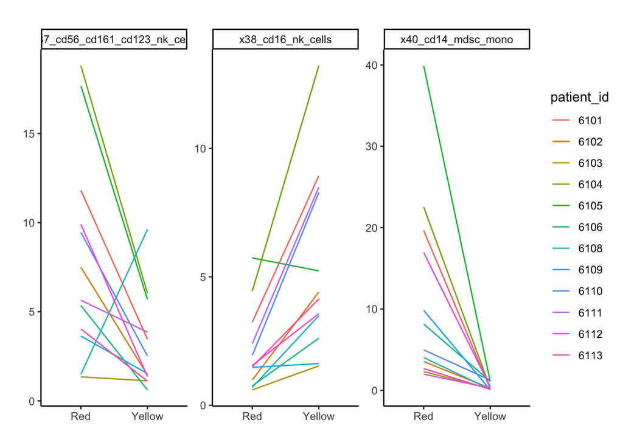

```r
cells_post_long_edited %>%
  filter(cell_type %in% sigcells_trt) %>%
  ggplot(aes(x = intervention, y = cell_value, color = patient_id)) +
  geom_line(aes(group = patient_id)) +
  labs(x = "",
       y = "",
       title = "") +
  theme_classic() +
  facet_wrap(~ cell_type, scales = "free_y")
```

##### boxplots

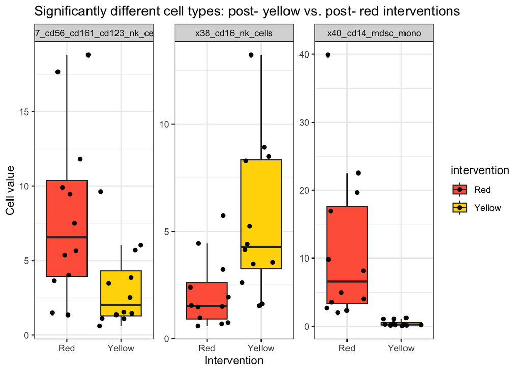

```r
cells_post_long_edited %>%
  filter(cell_type %in% sigcells_trt) %>%
  ggplot(aes(x = intervention, y = cell_value, fill = intervention)) +
  geom_boxplot(outlier.shape = NA) +
  scale_fill_manual(values = c("Yellow" = "gold",
                               "Red" = "tomato1")) +
  geom_jitter() +
  labs(x = "Intervention",
       y = "Cell value",
       title = "Significantly different cell types: post- yellow vs. post- red interventions") +
  facet_wrap(~ cell_type, ncol = 3, nrow = 1, scales = "free_y") +
  theme_bw()
```

- x38_CD16 NK cells are **significantly higher** in post- yellow compared to post-red
- x37_cd56_cd161_cd123_nk_cells and x40_cd14_mdsc_mono **significantly lower** post-yellow intervention compared to post-red

### Yellow juice treatment

```r
# subset data into yellow results
cells_Y_long <- cells_long %>%
  filter(intervention == "Yellow")
```

```r
# remove x41_cd66b_mdsc_grans because it has too many NAs
cells_Y_long_edited <- cells_Y_long %>%
  filter(cell_type != "x41_cd66b_mdsc_grans")
```

```r
# treatment effect test lmer model function
cells_trtY_function <- function(cells_Y_long_edited) {
  lmer(cell_value ~ pre_post + (1|patient_id),
       data = cells_Y_long_edited,
       REML = TRUE)
}

# break data up into subsets based on cytokine, then apply funtion to each subset
cells_trtY_models <- map(split(cells_Y_long_edited,
                              cells_Y_long_edited$cell_type),
                        cells_trtY_function)

# create single data frame of results by applying the lmer function to each element in list. apply tidy from broom.mixed package to clean up results
cells_trtY_results <- map_df(cells_trtY_models,
                            tidy,
                            .id = "cell_type")

# extract fixed coefficients for sequence only
cells_trtY_coefonly <- cells_trtY_results %>%
  filter(effect == "fixed") %>%
  filter(term != "(Intercept)") %>%
  add_significance(p.col = "p.value",
                   output.col = "p.sig",
                   cutpoints = c(0, 1e-04, 0.001, 0.01, 0.05, 1),
                   symbols = c("****", "***", "**", "*", "ns")
                   )
```

Results

```r
# extract statistically significant cytokines
cells_trtY_psig <- cells_trtY_coefonly %>%
  filter(cells_trtY_coefonly$p.value < 0.05)

print(cells_trtY_psig$cell_type)
```

```
## [1] "x05_cd4_cd8_cd8_t_cells"     "x08_cd45ro_cd45ra_em_cd8"
## [3] "x09_cd45r0_cd45ra_te_cd8"    "x15_cd45ro_cd45ra_te_cd4"
## [5] "x26_cd27_ig_d_naive_b_cells"
```

#### Plots

```r
sigcells_Y <- cells_trtY_psig$cell_type
```

##### lineplots

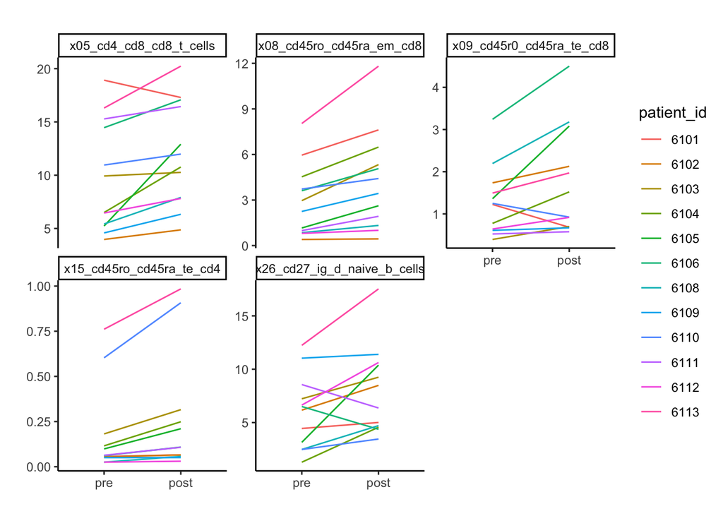

```r
cells_Y_long_edited %>%
  filter(cell_type %in% sigcells_Y) %>%
  ggplot(aes(x = pre_post, y = cell_value, color = patient_id)) +
  geom_line(aes(group = patient_id)) +
  labs(x = "",
       y = "",
       title = "") +
  theme_classic() +
  facet_wrap(~ cell_type, scales = "free_y")
```

##### boxplots

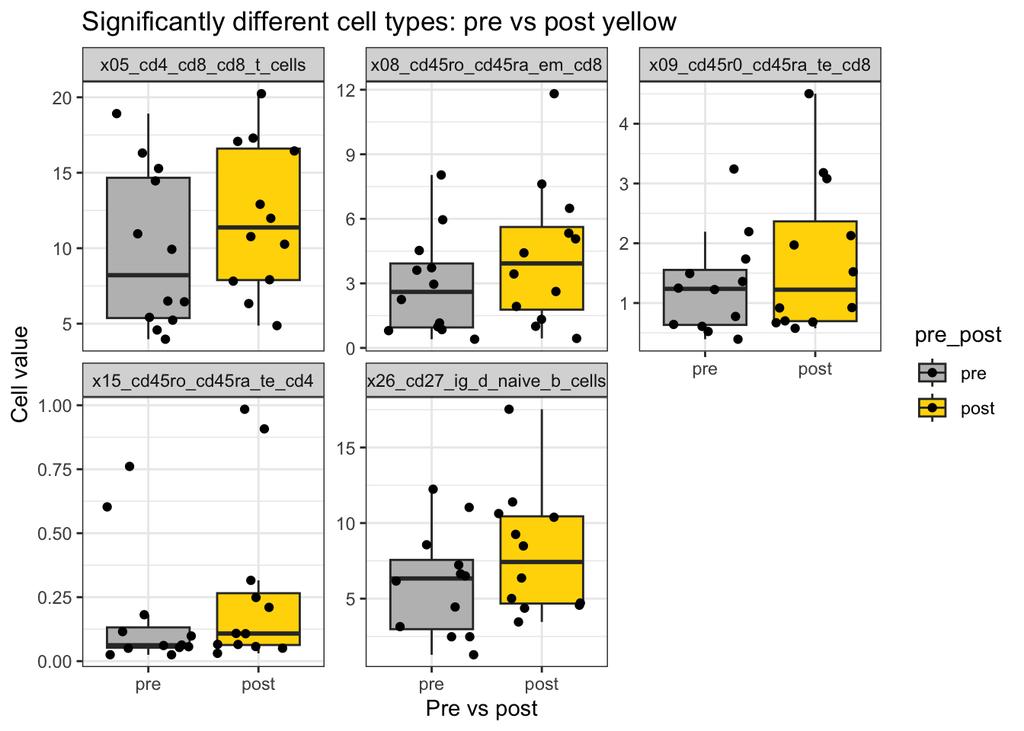

```r
cells_Y_long_edited %>%
  filter(cell_type %in% sigcells_Y) %>%
  ggplot(aes(x = pre_post, y = cell_value, fill = pre_post)) +
  geom_boxplot(outlier.shape = NA) +
  scale_fill_manual(values = c("pre" = "gray",
                               "post" = "gold")) +
  geom_jitter() +
  labs(x = "Pre vs post",
       y = "Cell value",
       title = "Significantly different cell types: pre vs post yellow") +
  facet_wrap(~ cell_type, ncol = 3, nrow = 2, scales = "free_y") +
  theme_bw()
```

*5 significant cell types

### Red juice treatment

```r
# subset data into red results
cells_R_long <- cells_long %>%
  filter(intervention == "Red")
```

```r
# remove x41_cd66b_mdsc_grans because it has too many NAs
cells_R_long_edited <- cells_R_long %>%
  filter(cell_type != "x41_cd66b_mdsc_grans")
```

```r
# treatment effect test lmer model function
cells_trtR_function <- function(cells_R_long_edited) {
  lmer(cell_value ~ pre_post + (1|patient_id),
       data = cells_R_long_edited,
       REML = TRUE)
}

# break data up into subsets based on cell, then apply funtion to each subset
cells_trtR_models <- map(split(cells_R_long_edited,
                               cells_R_long_edited$cell_type),
                         cells_trtR_function)

# create single data frame of results by applying the lmer function to each element in list. apply tidy from broom.mixed package to clean up results
cells_trtR_results <- map_df(cells_trtR_models,
                             tidy,
                             .id = "cell_type")

# extract fixed coefficients for sequence only
cells_trtR_coefonly <- cells_trtR_results %>%
  filter(effect == "fixed") %>%
  filter(term != "(Intercept)") %>%
  add_significance(p.col = "p.value",
                   output.col = "p.sig",
                   cutpoints = c(0, 1e-04, 0.001, 0.01, 0.05, 1),
                   symbols = c("****", "***", "**", "*", "ns")
                   )
```

Results

```r
kable(cells_trtR_coefonly, format = "markdown", digits = 3)
```

| cell_type | effect | group | term | estimate | std.error | statistic | df | p.value | p.sig |
| --- | --- | --- | --- | --- | --- | --- | --- | --- | --- |
| x01_cd45_cd66b_lymph_dc_mono | fixed | NA | pre_postpost | -0.476 | 0.978 | -0.487 | 11 | 0.636 | ns |
| x02_cd45_cd66b_grans | fixed | NA | pre_postpost | 0.354 | 0.228 | 1.556 | 11 | 0.148 | ns |
| x03_cd3_cd45_cd3_t_cells | fixed | NA | pre_postpost | 0.294 | 6.161 | 0.048 | 11 | 0.963 | ns |
| x04_tc_rgd_cd3_ab_t_cells | fixed | NA | pre_postpost | 0.086 | 6.144 | 0.014 | 11 | 0.989 | ns |
| x05_cd4_cd8_cd8_t_cells | fixed | NA | pre_postpost | 1.983 | 1.198 | 1.655 | 11 | 0.126 | ns |
| x06_cd45ro_cd45ra_naive_cd8 | fixed | NA | pre_postpost | 0.137 | 0.463 | 0.296 | 11 | 0.773 | ns |
| x07_cd46ro_cd45ra_cm_cd8 | fixed | NA | pre_postpost | 0.063 | 0.049 | 1.296 | 11 | 0.221 | ns |
| x08_cd45ro_cd45ra_em_cd8 | fixed | NA | pre_postpost | 1.645 | 1.099 | 1.496 | 11 | 0.163 | ns |
| x09_cd45r0_cd45ra_te_cd8 | fixed | NA | pre_postpost | 0.147 | 0.191 | 0.770 | 11 | 0.457 | ns |
| x10_cd38_hladr_activated_cd8 | fixed | NA | pre_postpost | -0.005 | 0.014 | -0.346 | 11 | 0.736 | ns |
| x11_cd4_cd8_cd4_t_cells | fixed | NA | pre_postpost | -2.279 | 5.045 | -0.452 | 11 | 0.660 | ns |
| x12_cd45ro_cd45ra_naive_cd4 | fixed | NA | pre_postpost | -1.932 | 2.696 | -0.717 | 11 | 0.488 | ns |
| x13_cd45ro_cd45ra_cm_cd4 | fixed | NA | pre_postpost | -0.585 | 0.924 | -0.633 | 11 | 0.540 | ns |
| x14_cd45ro_cd45ra | fixed | NA | pre_postpost | 0.374 | 0.255 | 1.467 | 11 | 0.170 | ns |
| x15_cd45ro_cd45ra_te_cd4 | fixed | NA | pre_postpost | 1.147 | 1.105 | 1.037 | 22 | 0.311 | ns |
| x16_cd38_hladr_activated_cd4 | fixed | NA | pre_postpost | -0.041 | 0.031 | -1.304 | 11 | 0.219 | ns |
| x17_cd25_cd127_tregs | fixed | NA | pre_postpost | -0.063 | 0.070 | -0.903 | 11 | 0.386 | ns |
| x18_ccr4_cd4_total_ccr4_treg | fixed | NA | pre_postpost | -0.056 | 0.058 | -0.967 | 11 | 0.354 | ns |
| x19_cd45ra_cd45ro_ccr4_treg_naive | fixed | NA | pre_postpost | -0.003 | 0.004 | -0.741 | 11 | 0.474 | ns |
| x20_hladr_total_ccr4_treg_activated | fixed | NA | pre_postpost | -0.006 | 0.025 | -0.238 | 11 | 0.816 | ns |
| x21_cd45ra_cd45ro_ccr4_treg_memory | fixed | NA | pre_postpost | -0.041 | 0.047 | -0.885 | 11 | 0.395 | ns |
| x22_cxcr3_ccr6_th1 | fixed | NA | pre_postpost | 0.631 | 0.511 | 1.234 | 11 | 0.243 | ns |
| x23_cxcr3_ccr6_th2 | fixed | NA | pre_postpost | -4.914 | 4.239 | -1.159 | 11 | 0.271 | ns |
| x24_cxcr3_ccr6_th17 | fixed | NA | pre_postpost | -0.076 | 0.433 | -0.175 | 11 | 0.864 | ns |
| x25_cd19_cd3_b_cells | fixed | NA | pre_postpost | 2.985 | 0.809 | 3.690 | 11 | 0.004 | ** |
| x26_cd27_ig_d_naive_b_cells | fixed | NA | pre_postpost | 2.506 | 0.771 | 3.250 | 11 | 0.008 | ** |
| x27_cd27_ig_d_memory_b_cells | fixed | NA | pre_postpost | 0.163 | 0.154 | 1.055 | 11 | 0.314 | ns |
| x28_cd27_ig_d_memory_resting_b_cells | fixed | NA | pre_postpost | 0.061 | 0.028 | 2.152 | 11 | 0.054 | ns |
| x30_cd27_cd38_plasmablasts | fixed | NA | pre_postpost | -0.018 | 0.018 | -1.004 | 11 | 0.337 | ns |
| x31_cd14_monocytes | fixed | NA | pre_postpost | -2.571 | 4.172 | -0.616 | 11 | 0.550 | ns |
| x32_cd16_non_classical_mono | fixed | NA | pre_postpost | -0.594 | 0.483 | -1.231 | 11 | 0.244 | ns |
| x33_cd16_classical_mono | fixed | NA | pre_postpost | -1.970 | 3.736 | -0.527 | 11 | 0.608 | ns |
| x34_hladr_cd56 | fixed | NA | pre_postpost | -2.146 | 3.763 | -0.570 | 11 | 0.580 | ns |
| x35_cd16_cd123_cd11c_p_dc | fixed | NA | pre_postpost | -0.078 | 0.060 | -1.301 | 11 | 0.220 | ns |
| x36_cd16_cd123_cd11c_m_dc | fixed | NA | pre_postpost | -1.310 | 3.138 | -0.417 | 11 | 0.684 | ns |
| x37_cd56_cd161_cd123_nk_cells | fixed | NA | pre_postpost | -1.292 | 1.590 | -0.812 | 11 | 0.434 | ns |
| x38_cd16_nk_cells | fixed | NA | pre_postpost | -0.601 | 0.521 | -1.153 | 11 | 0.273 | ns |
| x40_cd14_mdsc_mono | fixed | NA | pre_postpost | -1.314 | 2.014 | -0.652 | 11 | 0.528 | ns |

```r
# extract statistically significant cells
cells_trtR_psig <- cells_trtR_coefonly %>%
  filter(cells_trtR_coefonly$p.value < 0.05)


print(cells_trtR_psig$cell_type)
```

```
## [1] "x25_cd19_cd3_b_cells"        "x26_cd27_ig_d_naive_b_cells"
```

#### Plots

```r
sigcells_R <- cells_trtR_psig$cell_type
```

##### lineplots

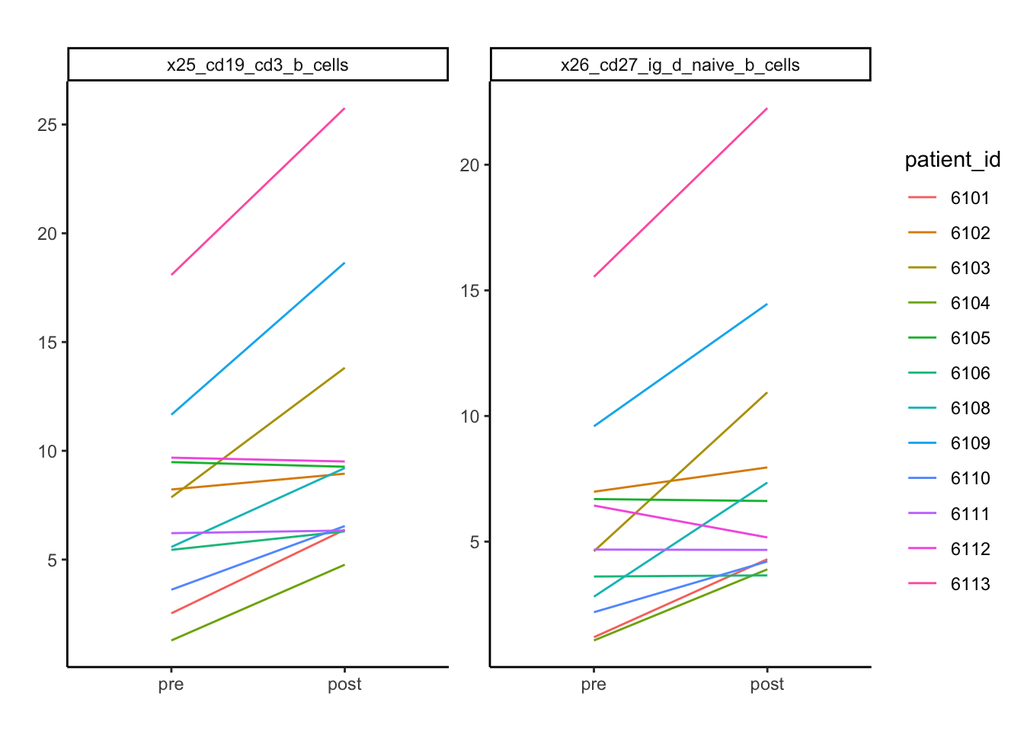

```r
cells_R_long_edited %>%
  filter(cell_type %in% sigcells_R) %>%
  ggplot(aes(x = pre_post, y = cell_value, color = patient_id)) +
  geom_line(aes(group = patient_id)) +
  labs(x = "",
       y = "",
       title = "") +
  theme_classic() +
  facet_wrap(~ cell_type, scales = "free_y")
```

##### boxplots

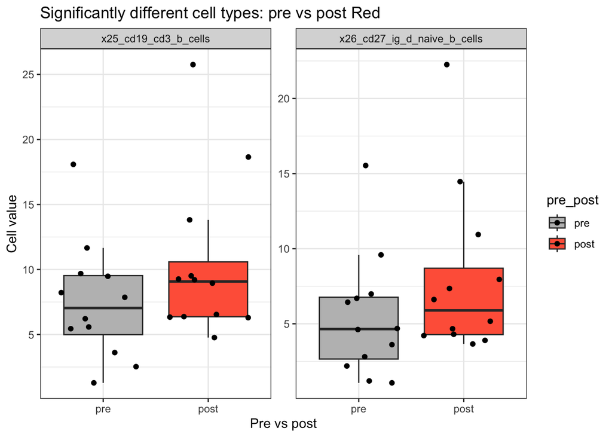

```r
cells_R_long_edited %>%
  filter(cell_type %in% sigcells_R) %>%
  ggplot(aes(x = pre_post, y = cell_value, fill = pre_post)) +
  geom_boxplot(outlier.shape = NA) +
  scale_fill_manual(values = c("pre" = "gray",
                               "post" = "tomato")) +
  geom_jitter() +
  labs(x = "Pre vs post",
       y = "Cell value",
       title = "Significantly different cell types: pre vs post Red") +
  facet_wrap(~ cell_type, ncol = 3, nrow = 2, scales = "free_y") +
  theme_bw()
```

Naive B-cell pop (#26) significantly increase post-Red intervention, and also increase post-Yellow intervention. This could suggest there is a tomato effect.